# ml-correlation-regression

shobha mourya

April 21, 2019

# 1 Simple Linear Regression

To describe relationships between two numerical quantities.

Data anlaysis is about understanding relationships among variables. Exploring data with multiple varaibles requires new, more complex tools, but enables a richer set of comparisons.

You will characterize these relationships graphically, in the form of summary statistics, and through simple linear regression models.

# 2 Visualizing bivariate relationship

- Scatterplots
- Boxplots as discritized/conditioned scatterplots
- Characterizing bivariate relationships
- Creating scatterplots
- Characterizing scatterplots
- Transformations
- Outliers
- Identifying outliers

# 3 Correlation to quantify the bivariate relationship

- Quantifying the strength of bivariate relationships
- Understanding correlations scale
- Understanding correlation sign
- Computing correlation
- The Anscombe dataset
- Exploring Anscombe
- Perception of correlation
- Interpretation of correlation
- Interpreting correlation in context
- Correlation and causation
- Spurious correlation
- Spurious correlation in random data

# 4 Simple Linear Regression Model

- Visualization of linear models
- The ‘best fit’ line
- Uniqueness of least squares regression line
- Understanding the linear model
- Regression model terminology
- Regression model output terminology
- Fitting a linear model ‘by hand’
- Regression vs. regression to the mean
- Regression to the mean
- ‘Regression’ in the parlance of our time

# 5 Interpreting coefficients of the regression model

- Interpretation of regression coefficients
- Interpretaion of coefficients
- Interpretation in context
- Fitting simple linear models
- Units ad scale
- Your linear model object
- The lm summary output
- Fitted values and residuals
- Tidying your linear model
- Using your linear model
- Making predictions
- Adding a regression line to a plot manually

# 6 Model Fit

How to asses the fit of the linear regression model

- Assessing model fit
- RMSE
- Standard error of residuals
- Comparing model fits
- Assessing simple linear model fit
- Interpretation of R^2
- Linear vs. average
- Unusual points
- Leverage
- Influence
- Dealing with unusual points
- Removing outliers
- High leverage points
- Conclusion

# 7 Response variable vs Explanatory variable

Modeling bivariate relatioships

In many cases we’re interesting in understanding the relationship between two variables. Both variables are numerical, we will quantify the relationship between two numeric variables

In a statistical model we have one variable which is the output and more than one variables that are the inputs.

Response variable * the output variable a.k.a. y, dependent * denoted with letter y * this is the quantity we feel might be related to the input

Explanatory variable * somthing you think might be related to the reponse * a.k.a. x, independent, predictor * in this course we will have a single explanatory variable but in the next course we will have several

# 8 Scatter plot for bivariate distribution

Scatterplots are the most common and effective tools for visualizing the relationship between two numeric variables.

Graphical representations

- just as you learned to visualize one variable the histogram, or the density plot, statisticians have developed a way of visualizing two numerical variables
- the scatter plot which is the most useful invention in the history of statistical graphics
- it does a simple two-dimensional plot in which the two coordinates of each dot represent the value of a variable measured on a single observation
- by convention we put the response variable on the verticle or y axis
- and the explanatory variable on the horizontal or x-axis
- in ggplot we bind the aesthetics to our reponse and exploratory variables and then use the geom_point() function to actually draw the points

Install and Load these packages in RStudio for the rmd file to compile and produce the output - in this case html file.

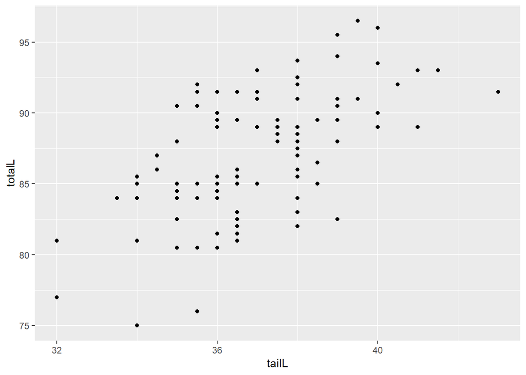

```r
library(ggplot2)
library(openintro)
library(dplyr)
library("tidyr")
library(readr)
ggplot(data = possum, aes(y = totalL, x = tailL)) +
  geom_point()
```

- to give your axis human readable variables use functions
1. scale_x_conginuous and
2. scale_y_continuous

```r
ggplot(data = possum, aes(y = totalL, x = tailL)) +
  geom_point() +
  scale_x_continouos("Length of Possum Tail (cm)") +
  scale_y_continuous("Length of Possum Body (cm)")
```

# 9 Discritizing explanatory variable for boxplot

{opposite of continuous is discrete - to discretize means convert into discrete values of bins}

- boxplot can illustrate the relationship between a numerical response variable and a categorical explanatory variable
- it may be helpful to think of scatter plots as a generalization of side-by-side boxplots
- we can connect these ideas by discritizing our explanatory variable
- this can be achieved in R using the cut() function which takes a numeric vector and chops it into discrete chunks
- the breaks argument specifies the number of chunks
- break the possums based on their tail length into five groups

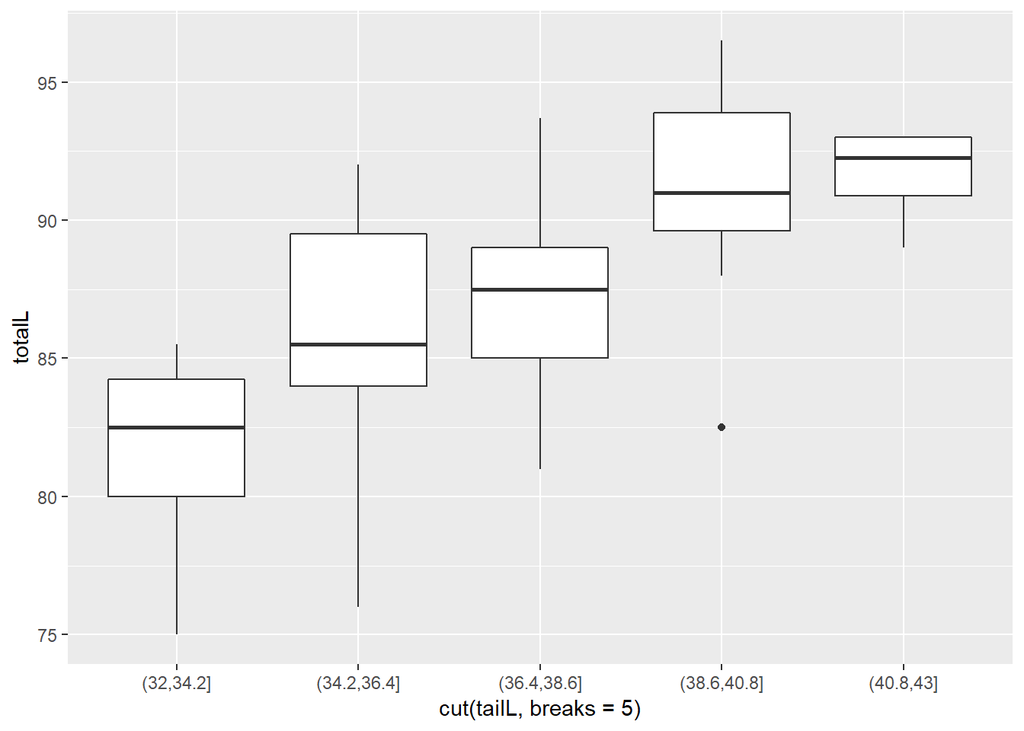

```r
ggplot(data = possum, aes(y = totalL, x = cut(tailL,
                                              breaks = 5))) +
  geom_boxplot()
```

Note how median line increases as tail length increases across the five groups

Boxplots as discretized/conditioned scatterplots If it is helpful, you can think of boxplots as scatterplots for which the variable on the x-axis has been discretized.

The cut() function takes two arguments: the continuous variable you want to discretize and the number of breaks that you want to make in that continuous variable in order to discretize it.

# 10 ncbirths dataset in openintro library

The ncbirths dataset is a random sample of 1,000 cases taken from a larger dataset collected in 2004. Each case describes the birth of a single child born in North Carolina, along with various characteristics of the child (e.g. birth weight, length of gestation, etc.), the child’s mother (e.g. age, weight gained during pregnancy, smoking habits, etc.) and the child’s father (e.g. age). You can view the help file for these data by running ?ncbirths in the console.

```r
library(ggplot2)
library(dplyr)
library(openintro)
data(ncbirths)

glimpse(ncbirths)
```

```
## Observations: 1,000
## Variables: 13
## $ fage           <int> NA, NA, 19, 21, NA, NA, 18, 17, NA, 20, 30, NA,...
## $ mage           <int> 13, 14, 15, 15, 15, 15, 15, 15, 16, 16, 16, 16,...
## $ mature         <fct> younger mom, younger mom, younger mom, younger ...
## $ weeks          <int> 39, 42, 37, 41, 39, 38, 37, 35, 38, 37, 45, 42,...
## $ premie         <fct> full term, full term, full term, full term, ful...
## $ visits         <int> 10, 15, 11, 6, 9, 19, 12, 5, 9, 13, 9, 8, 4, 12...
## $ marital        <fct> married, married, married, married, married, ma...
## $ gained         <int> 38, 20, 38, 34, 27, 22, 76, 15, NA, 52, 28, 34,...
## $ weight         <dbl> 7.63, 7.88, 6.63, 8.00, 6.38, 5.38, 8.44, 4.69,...
## $ lowbirthweight <fct> not low, not low, not low, not low, not low, lo...
## $ gender         <fct> male, male, female, male, female, male, male, m...
## $ habit          <fct> nonsmoker, nonsmoker, nonsmoker, nonsmoker, non...
## $ whitemom       <fct> not white, not white, white, white, not white, ...
```

Using the ncbirths dataset, make a scatterplot using ggplot() to illustrate how the birth weight of these babies varies according to the number of weeks of gestation.

```r
names(ncbirths)
```

```
##  [1] "fage"           "mage"           "mature"         "weeks"
##  [5] "premie"         "visits"         "marital"        "gained"
##  [9] "weight"         "lowbirthweight" "gender"         "habit"
## [13] "whitemom"
```

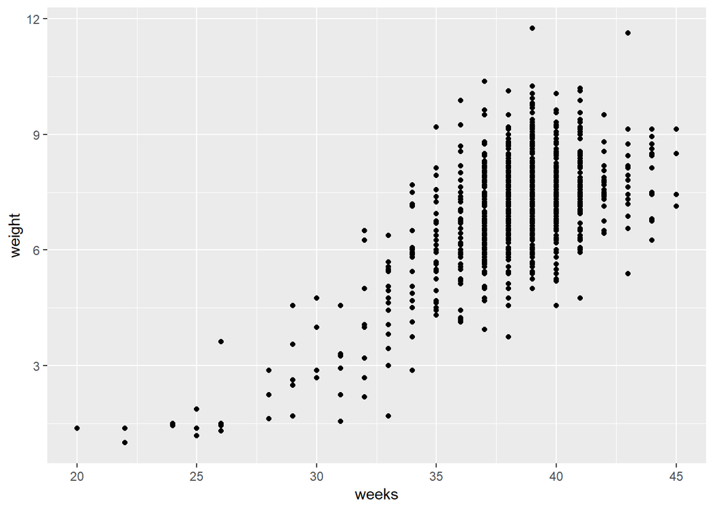

```r
# Scatterplot of weight vs. weeks
ggplot(ncbirths, aes(x = weeks, y = weight)) +
  geom_point()
```

Using the ncbirths dataset again, make a boxplot illustrating how the birth weight of these babies varies according to the number of weeks of gestation. This time, use the cut() function to discretize the x-variable into six intervals (i.e. five breaks).

```r
str(ncbirths$weeks)
```

```
##  int [1:1000] 39 42 37 41 39 38 37 35 38 37 ...
```

```r
#int [1:1000] 39 42 37 41 39 38 37 35 38 37 ...

str(ncbirths$weight)
```

```
##  num [1:1000] 7.63 7.88 6.63 8 6.38 5.38 8.44 4.69 8.81 6.94 ...
```

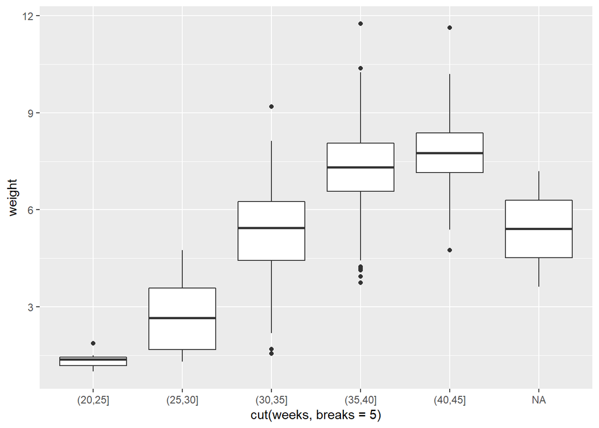

```r
#num [1:1000] 7.63 7.88 6.63 8 6.38 5.38 8.44 4.69 8.81 6.94 ...

# Boxplot of weight vs. weeks
ggplot(data = ncbirths,
       aes(x = cut(weeks, breaks = 5), y = weight)) +
  geom_boxplot()
```

Conclusion: Great! Note how the relationship no longer seems linear.

# 11 Characterizing bivariate relationships form, direction, strength and outliers

- scatter plots can reveal characteristics of the relationship between two variables
- any deviation isn the patterns in these plots can give us insight into the nature of the underlying phenomena
- specifically we look for four things
- form, direction, strength, and outliers

## 11.1 Form

- form is the overall shape made by the points (e.g. linear, quadratic, non-linear), since we’re looking at linear regression our primary concern would be whether the form is linear or non-linear

## 11.2 Direction

- direction (e.g. positive, negative)
- here the question is whether the two variables tend to move in same direction, that is when one goes up the other tends to go up or in the opposite direction

## 11.3 Strength

- strength (how much scatter/noise?)
- how much scatter is present
- do the points seem clustered together in a way that suggests a close relationship
- or are they very loosely organized

## 11.4 Outliers

- any points that don’t fit the overall pattern will simply lie far away are important to investigate
- these outliers may be erroroneous measurements
- where there can be exceptions that help clarify the general trend
- either way outliers can be revealing
- we’ll learn more about them later

# 12 Interpreting scatterplot

- do a google image search for scatter plots and interprete the bivariate relationships
- interpreting the scatter plot is like making judgement calls at this stage
- this is part of the nature of statistics and while it can frustrating especially as a beginner it is inescapable
- for better or for worse Statistics is one field where there is no right answer
- there are of course and indefensible number of indefinite claims but many judgements are open to interpretations

## 12.1 Example 1 : scatter plot of Sign legibility

Sign Legibility Distance (feet) vs Driver Age(years)

## 12.5 Example 4 : Fan shape scatter plot

# 13 Creating scatterplots

Creating scatterplots is simple and they are so useful that is it worthwhile to expose yourself to many examples. Over time, you will gain familiarity with the types of patterns that you see. You will begin to recognize how scatterplots can reveal the nature of the relationship between two variables.

We will be using several datasets listed below. These data are available through the openintro package.

Briefly:

## 13.2 The mlbBat10 dataset

- contains batting statistics for 1,199 Major League Baseball players during the 2010 season.

## 13.3 The bdims dataset

- contains body girth and skeletal diameter measurements for 507 physically active individuals.

## 13.4 The smoking dataset

- contains information on the smoking habits of 1,691 citizens of the United Kingdom.

To see more thorough documentation, use the ? or help() functions

# 14 Transformations

The relationship between two variables may not be linear. In these cases we can sometimes see strange and even inscrutable patterns in a scatterplot of the data. Sometimes there really is no meaningful relationship between the two variables. Other times, a careful transformation of one or both of the variables can reveal a clear relationship.

Recall the bizarre pattern that you saw in the scatterplot between brain weight and body weight among mammals in a previous exercise. Can we use transformations to clarify this relationship?

ggplot2 provides several different mechanisms for viewing transformed relationships.

## 14.1 The coord_trans() function

Transforms the coordinates of the plot.

## 14.2 Alternatively, the scale_x_log10() and scale_y_log10() functions

Perform a base-10 log transformation of each axis.

Note the differences in the appearance of the axes.

Using the mammals dataset, create a scatterplot illustrating how the brain weight of a mammal varies as a function of its body weight.

```r
nrow(mammals)
```

```
## [1] 62
```

```r
names(mammals)
```

```
##  [1] "Species"     "BodyWt"      "BrainWt"     "NonDreaming" "Dreaming"
##  [6] "TotalSleep"  "LifeSpan"    "Gestation"   "Predation"   "Exposure"
## [11] "Danger"
```

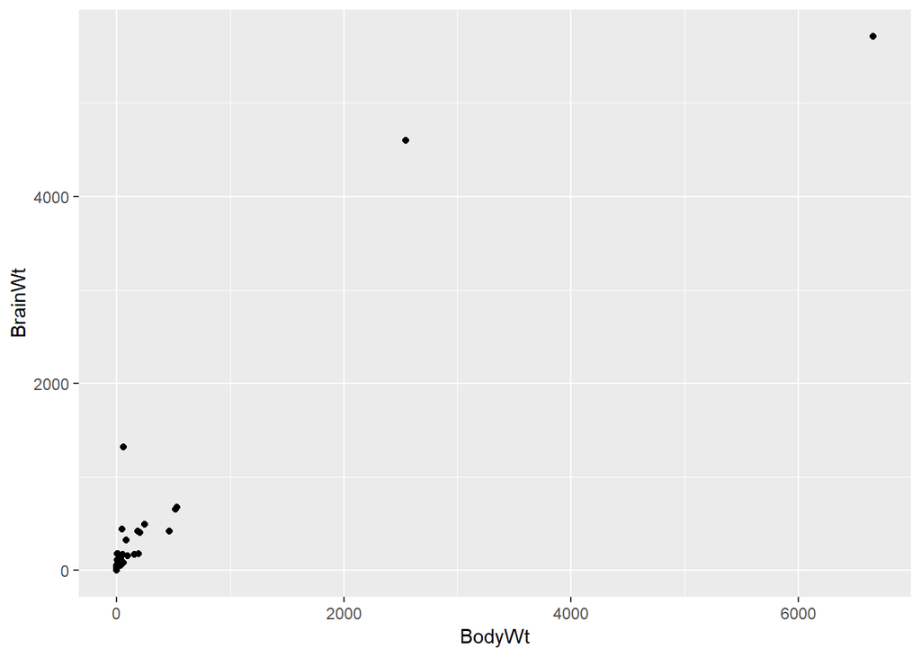

```r
# BrianWt ~ BodyWt
ggplot(mammals, aes(x = BodyWt, y = BrainWt)) +
  geom_point()
```

Use coord_trans() to create a scatterplot showing how a mammal’s brain weight varies as a function of its body weight, where both the x and y axes are on a ‘log10’ scale.

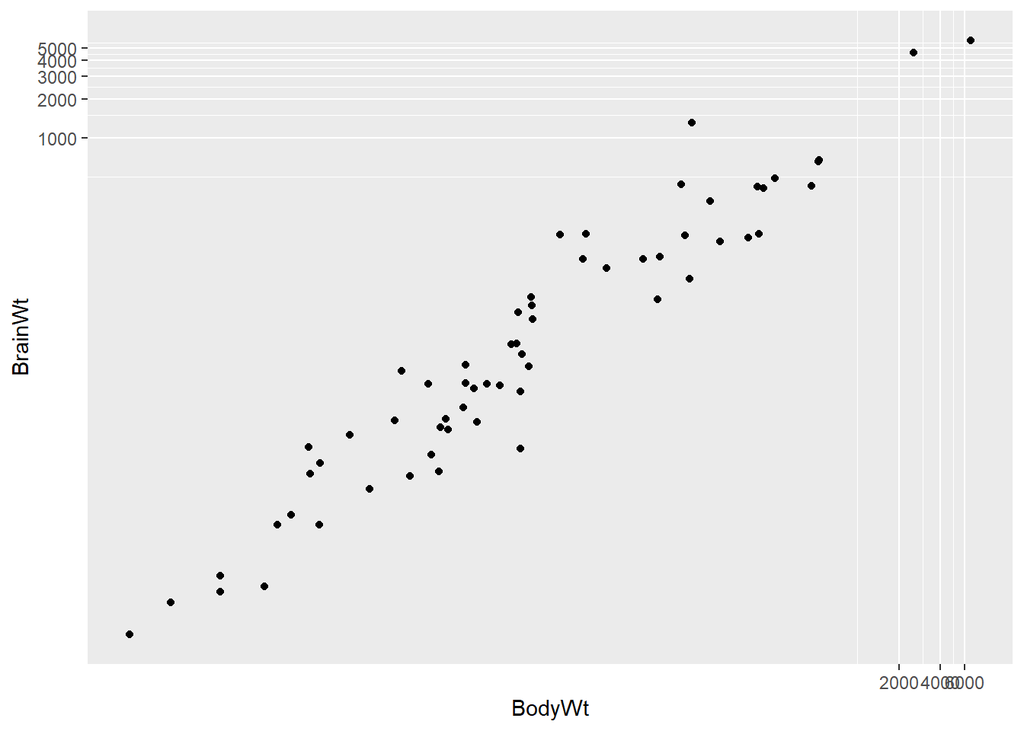

```r
# Scatterplot with coord_trans()
ggplot(data = mammals, aes(x = BodyWt, y = BrainWt)) +
  geom_point() +
  coord_trans(x = "log10", y = "log10")
```

{ this one just zooms in the co-ordinates section }

Use scale_x_log10() and scale_y_log10() to achieve the same effect but with different axis labels and grid lines.

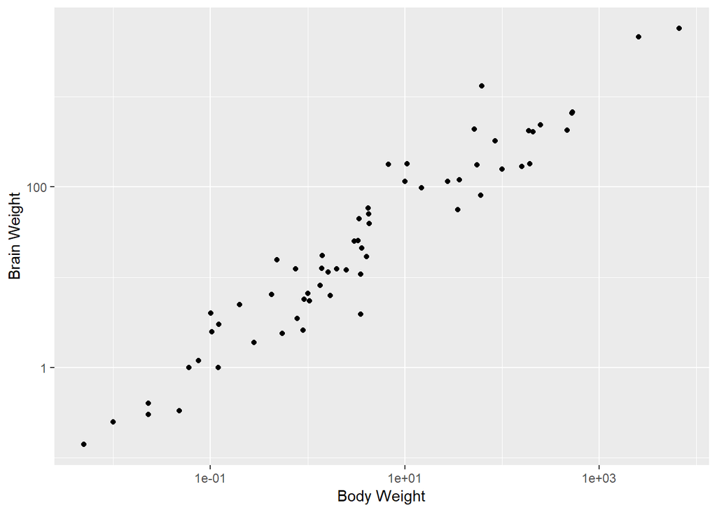

```r
ggplot(data = mammals, aes(x = BodyWt, y = BrainWt)) +
  geom_point() +
  scale_x_log10("Body Weight") +
  scale_y_log10("Brain Weight")
```

{ this is the best as it scales both the axes and grid lines}

Using the mlbBat10 dataset, create a scatterplot illustrating how the slugging percentage (SLG) of a player varies as a function of his on-base percentage (OBP).

```r
nrow(mlbBat10)
```

```
## [1] 1199
```

```r
names(mlbBat10)
```

```
##  [1] "name"     "team"     "position" "G"        "AB"       "R"
##  [7] "H"        "2B"       "3B"       "HR"       "RBI"      "TB"
## [13] "BB"       "SO"       "SB"       "CS"       "OBP"      "SLG"
## [19] "AVG"
```

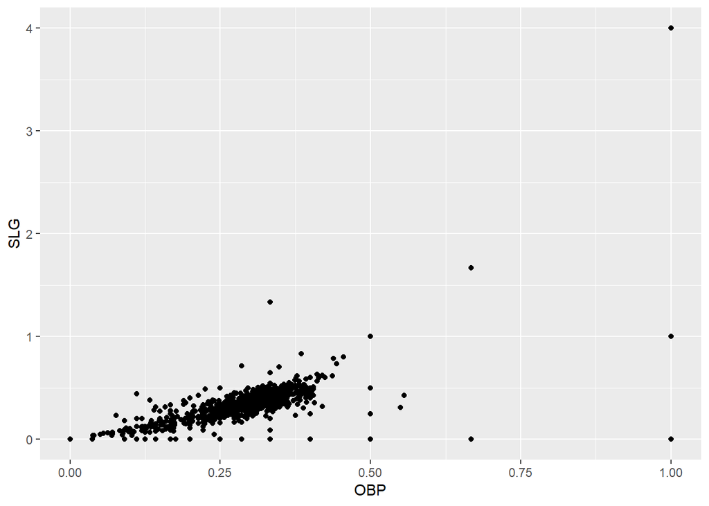

```r
# SLG ~ OBP
ggplot(mlbBat10, aes(x = OBP, y = SLG)) +
  geom_point()
```

Using the bdims dataset, create a scatterplot illustrating how a person’s weight varies as a function of their height. Use color to separate by sex, which you’ll need to coerce to a factor with factor().

```r
nrow(bdims)
```

```
## [1] 507
```

```r
str(bdims$sex)
```

```
##  int [1:507] 1 1 1 1 1 1 1 1 1 1 ...
```

```r
unique(bdims$sex)
```

```
## [1] 1 0
```

```r
names(bdims)
```

```
##  [1] "bia.di" "bii.di" "bit.di" "che.de" "che.di" "elb.di" "wri.di"
##  [8] "kne.di" "ank.di" "sho.gi" "che.gi" "wai.gi" "nav.gi" "hip.gi"
## [15] "thi.gi" "bic.gi" "for.gi" "kne.gi" "cal.gi" "ank.gi" "wri.gi"
## [22] "age"    "wgt"    "hgt"    "sex"
```

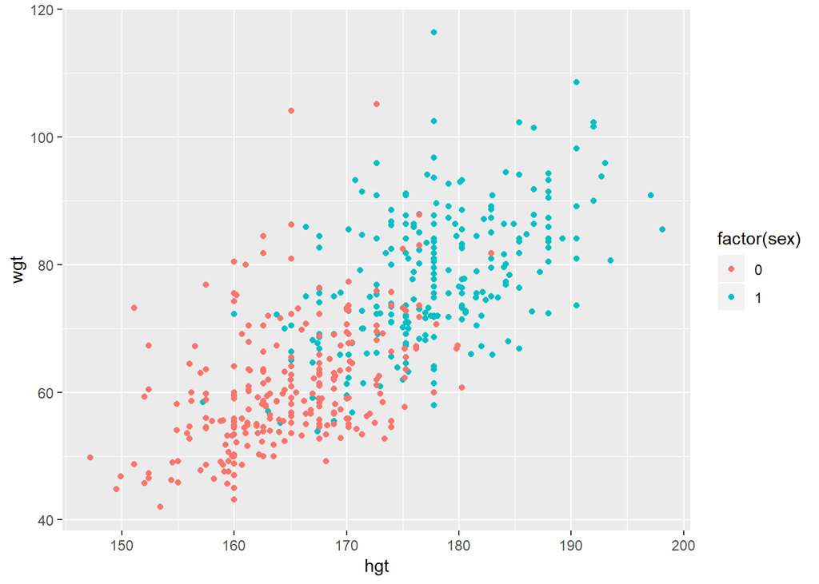

```r
# weight ~ height
ggplot(bdims, aes(x = hgt, y= wgt, col = factor(sex))) +
  geom_point()
```

Using the smoking dataset, create a scatterplot illustrating how the amount that a person smokes on weekdays varies as a function of their age

```r
nrow(smoking)
```

```
## [1] 1691
```

```r
names(smoking)
```

```
##  [1] "gender"               "age"                  "maritalStatus"
##  [4] "highestQualification" "nationality"          "ethnicity"
##  [7] "grossIncome"          "region"               "smoke"
## [10] "amtWeekends"          "amtWeekdays"          "type"
```

```
## Warning: Removed 1270 rows containing missing values (geom_point).
```

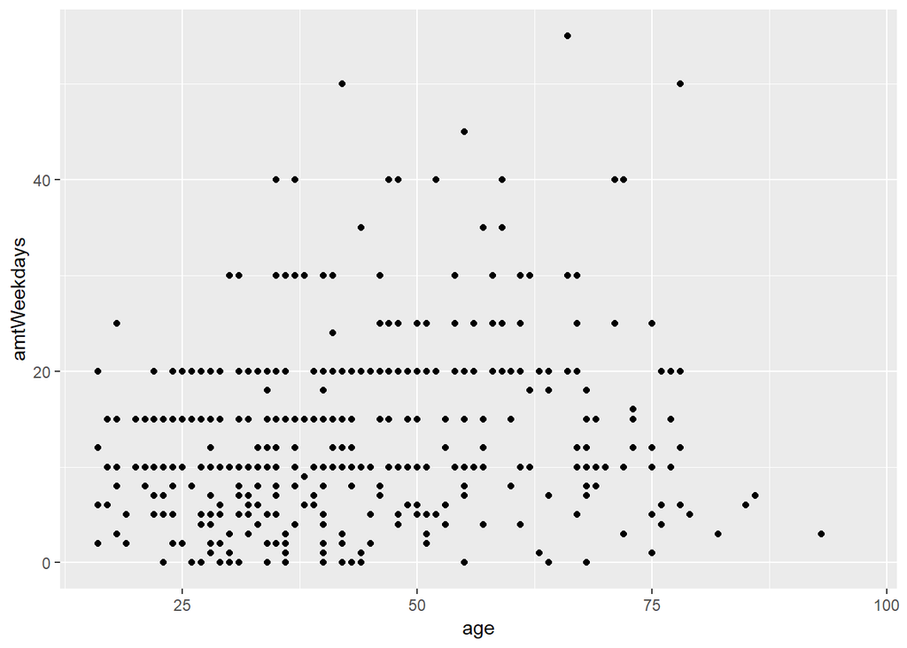

```r
# smoke on weekdays ~ age
ggplot(smoking, aes(x = age, y = amtWeekdays)) +
  geom_point()
```

Warning message: Removed 1270 rows containing missing values (geom_point).

# 15 Outliers

- observations that don’t seem to fit with the rest of the points maybe considered outliers
- there isn’t a hard and fast definition that constitutes an outlier
- but they are often easy to spot
- consider the below scatter plot of home runs hit by majorly baseball players 2010 and number of bases they stole
- homeruns are a measure of that in power ??? and stolen bases are a measure of footspeed
- it is not surprising that we see a negative relationship here since power and speed are generally considered complementary skills
- since both variables here are integer values, several of the observations have the same values, thus corresponding values are plotted on top of one another
- this can misrepresent the data
- to combat this we can add an alpha transparency to the points, making them more transluscent
- now we can see that over-plotting occurs where the darker dots are
- another approach is to add some jitter to the dots
- this is just a small amount of random noise neither in the x or the y direction
- this releaves the constraint of both having both coordinates be integers
- and thus allows us to see all the data
- in this plot there are two points that stand out as potential outliers
- one on the lower right hand corner and one right on top on left hand side
- we will see later how to handle these outliers
- for now we’ll see how to identify outliers

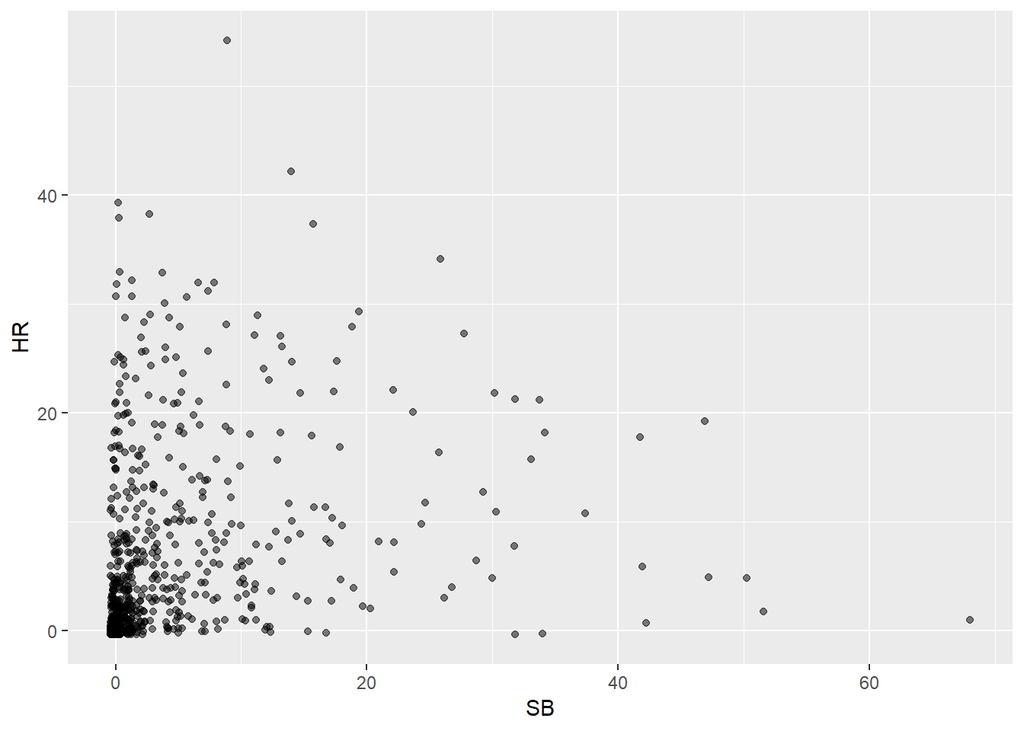

```r
ggplot(data = mlbBat10, aes(x = SB, y = HR)) +
  geom_point(alpha = 0.5, position = "jitter")
```

Identify the outliers

```r
mlbBat10 %>%
  filter(SB > 60 | HR > 50) %>%
  select(name, team, position, SB, HR)
```

```
##         name team position SB HR
## 1   J Pierre  CWS       OF 68  1
## 2 J Bautista  TOR       OF  9 54
```

```
    name team position SB HR
```

1 J Pierre CWS OF 68 1 2 J Bautista TOR OF 9 54

As it turns out Pierre is the player at the lower right hand corner who is speediest and the least powerful hitters in the recent memory. Whereas the player at the top is Jose Bautista, one of the game’s most revered sluggers

## 15.1 Identifying outliers

Here we will discuss how outliers can affect the results of a linear regression model and how we can deal with them. For now, it is enough to simply identify them and note how the relationship between two variables may change as a result of removing outliers.

Recall that in the baseball example earlier in the chapter, most of the points were clustered in the lower left corner of the plot, making it difficult to see the general pattern of the majority of the data. This difficulty was caused by a few outlying players whose on-base percentages (OBPs) were exceptionally high. These values are present in our dataset only because these players had very few batting opportunities.

Both OBP and SLG are known as rate statistics, since they measure the frequency of certain events (as opposed to their count). In order to compare these rates sensibly, it makes sense to include only players with a reasonable number of opportunities, so that these observed rates have the chance to approach their long-run frequencies.

In Major League Baseball, batters qualify for the batting title only if they have 3.1 plate appearances per game. This translates into roughly 502 plate appearances in a 162-game season. The mlbBat10 dataset does not include plate appearances as a variable, but we can use at-bats (AB) – which constitute a subset of plate appearances – as a proxy.

Use filter() to create a scatterplot for SLG as a function of OBP among players who had at least 200 at-bats.

```r
names(mlbBat10)
```

```
##  [1] "name"     "team"     "position" "G"        "AB"       "R"
##  [7] "H"        "2B"       "3B"       "HR"       "RBI"      "TB"
## [13] "BB"       "SO"       "SB"       "CS"       "OBP"      "SLG"
## [19] "AVG"
```

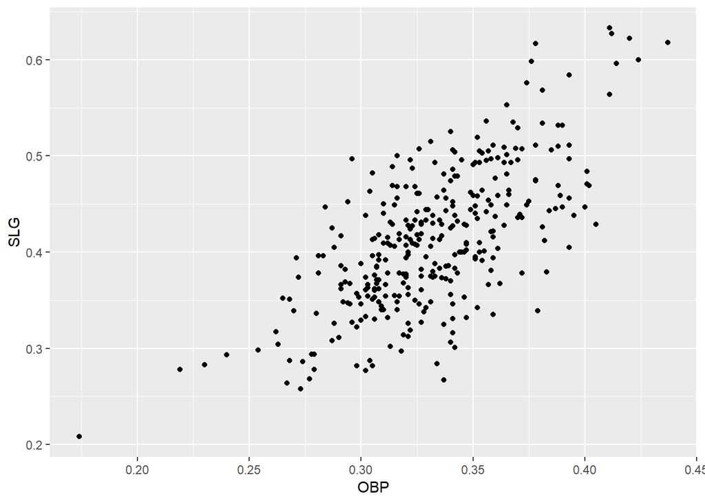

```r
mlbBat10 %>%
  filter(AB >= 200) %>%
  ggplot(aes(x = OBP, y = SLG)) +
  geom_point()
```

Find the row of mlbBat10 corresponding to the one player with at least 200 at-bats whose OBP was below 0.200.

```r
mlbBat10 %>%
  filter(AB >= 200, OBP < 0.200)
```

```
##     name team position  G  AB  R  H 2B 3B HR RBI TB BB SO SB CS   OBP
## 1 B Wood  LAA       3B 81 226 20 33  2  0  4  14 47  6 71  1  0 0.174
##     SLG   AVG
## 1 0.208 0.146
```

```
name team position  G  AB  R  H 2B 3B HR RBI TB BB SO SB CS   OBP   SLG
```

1 B Wood LAA 3B 81 226 20 33 2 0 4 14 47 6 71 1 0 0.174 0.208 AVG 1 0.146

# 16 Correlation

Quantifying the strength of bivariate relationships

- we saw how to visualize the strength linear relationship between two integer variables using scatter plot
- correlation is the way to quantify that strength of linear relationship
- the correlation coefficient is between -1 and 1
- that indicates the strength of the linear relationship
- the sign of the correlation coefficient corresponds to the direction, positive or negative
- the magnitude of the correlation coefficient corresponds to the strength
- a correlation coefficient near to 1, example 0.959, corresponds to near perfect positive correlation
- in a scatter plot where point are more spread out the corr coeff is low,
- 0.756 is strong, closer to 0.5 may be considered moderate and closer to 0.2 weak
- if there is really no linear relationship between the variables then corr coeff will be zero
- it is common to encounter variables that can be strongly related but in a non-linear way
- example curved scatter plots show quadratic relationship where x and y are closely related but just not in a linear fashion

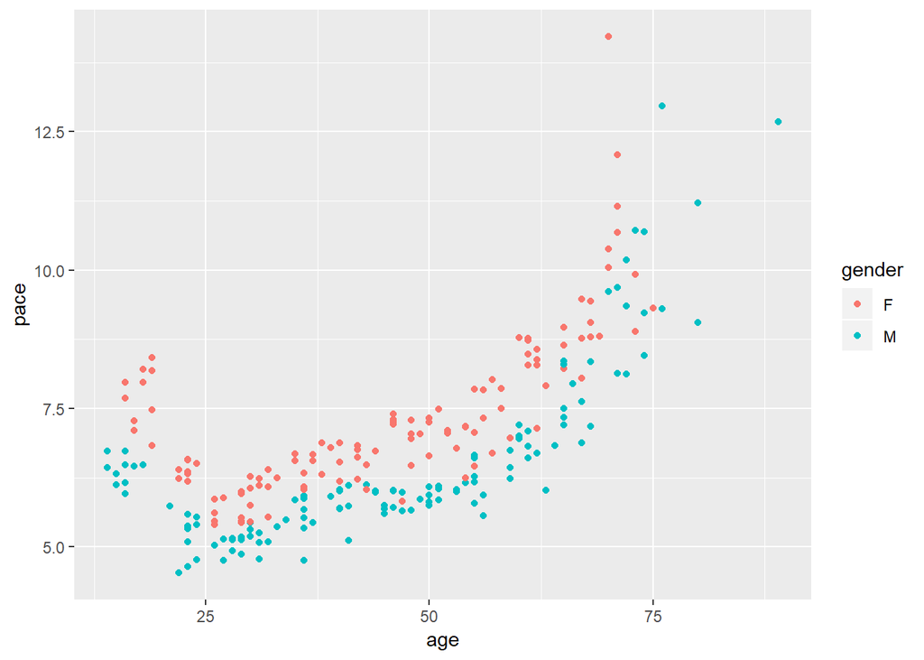

```r
# Non-linear correlation
run10 %>%
  filter(divPlace <= 10) %>%
  ggplot(aes(x = age, y = pace, color = gender)) +
  geom_point()
```

Notice how relationship between age and pace is non-linear

- 25 year olds tend to be faster than 20 year olds but as people age beyond 30 they tend to get slower
- and this pattern is present for both men and women
- the value of corr coeff here is about 0.68 but we can sense that age and pace are more closely related than the figure indicates
- there are several different ways that correlation can be defined in statistics but by far the most common is the Pearson product-moment correlation
- when we say correlation, we’re talking about this value other definitions are preferred in other contexts
- corr is denoted are r(x,y)
- it is the sum of deviation from mean for both x and y
- understanding correlation conceptually is more important than the mathematical expression

## 16.1 Understanding correlation scale

In a scientific paper, three correlations are reported with the following values:

-0.395 1.827 0.738

Choose the correct interpretation of these findings.

Possible Answers (1) is invalid.

2. is invalid.(Answer)
3. is invalid.

Both (1) and (2) are invalid.

Both (2) and (3) are invalid

Right! Correlation coefficients cannot be greater than 1.

## 16.2 Understanding correlation sign

In a scientific paper, three correlations are reported with the following values:

0.582 0.134 -0.795

Which of these values represents the strongest correlation?

Possible Answers

0.582

0.134

-0.795 (Answer)

Can’t tell!

Right!

## 16.3 Computing correlation using cor(x,y)

The cor(x, y) function will compute the Pearson product-moment correlation between variables, x and y. Since this quantity is symmetric with respect to x and y, it doesn’t matter in which order you put the variables.

At the same time, the cor() function is very conservative when it encounters missing data (e.g. NAs). The use argument allows you to override the default behavior of returning NA whenever any of the values encountered is NA. Setting the use argument to ‘pairwise.complete.obs’ allows cor() to compute the correlation coefficient for those observations where the values of x and y are both not missing.

Use cor() to compute the correlation between the birthweight of babies in the ncbirths dataset and their mother’s age. There is no missing data in either variable.

```r
names(ncbirths)
```

```
##  [1] "fage"           "mage"           "mature"         "weeks"
##  [5] "premie"         "visits"         "marital"        "gained"
##  [9] "weight"         "lowbirthweight" "gender"         "habit"
## [13] "whitemom"
```

```r
# Compute correlation
ncbirths %>%
  summarize(N = n(), r = cor(weight, mage))
```

```
##      N          r
## 1 1000 0.05506589
```

[output not shown]

Compute the correlation between the birthweight and the number of weeks of gestation for all non-missing pairs.

```r
# Compute correlation for all non-missing pairs
ncbirths %>%
  summarize(N = n(), r = cor(weight, weeks, use = "pairwise.complete.obs"))
```

```
##      N         r
## 1 1000 0.6701013
```

```
N         r
```

1 1000 0.6701013

# 17 The Anscombe dataset

In 1973 Statistician Francis Anscombe created a synthetic dataset which has been used ever since to illustrate concepts related to correlation & regression. By discussing these with you I will have fullfilled my obligatin as a competent statistics instructor

```r
names(anscombe)
```

```
## [1] "x1" "x2" "x3" "x4" "y1" "y2" "y3" "y4"
```

```r
glimpse(anscombe)
```

```
## Observations: 11
## Variables: 8
## $ x1 <dbl> 10, 8, 13, 9, 11, 14, 6, 4, 12, 7, 5
## $ x2 <dbl> 10, 8, 13, 9, 11, 14, 6, 4, 12, 7, 5
## $ x3 <dbl> 10, 8, 13, 9, 11, 14, 6, 4, 12, 7, 5
## $ x4 <dbl> 8, 8, 8, 8, 8, 8, 8, 19, 8, 8, 8
## $ y1 <dbl> 8.04, 6.95, 7.58, 8.81, 8.33, 9.96, 7.24, 4.26, 10.84, 4.82...
## $ y2 <dbl> 9.14, 8.14, 8.74, 8.77, 9.26, 8.10, 6.13, 3.10, 9.13, 7.26,...
## $ y3 <dbl> 7.46, 6.77, 12.74, 7.11, 7.81, 8.84, 6.08, 5.39, 8.15, 6.42...
## $ y4 <dbl> 6.58, 5.76, 7.71, 8.84, 8.47, 7.04, 5.25, 12.50, 5.56, 7.91...
```

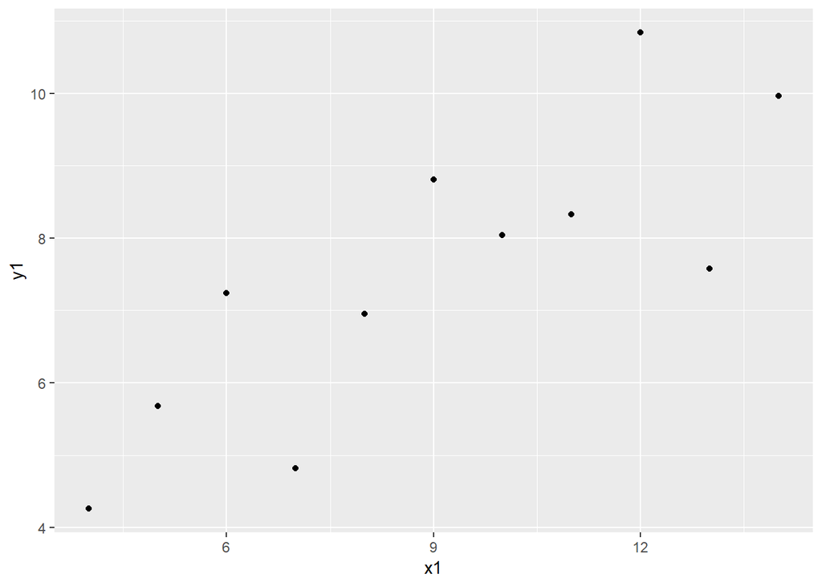

```r
ggplot(data = anscombe, aes(x = x1, y = y1)) +
  geom_point()
```

Here we see linear positvie moderate correlation with r = 0.82

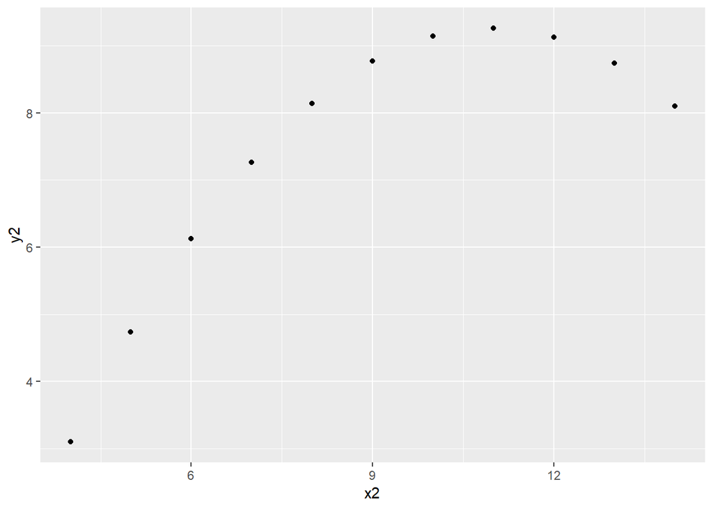

```r
ggplot(data = anscombe, aes(x = x2, y = y2)) +   geom_point()
```

Clearly non-linear but r = 0.82, that is knowing the value of x tells you the value of y perfectly. There is no statistical noise, it’s just that the relationship is non-linear

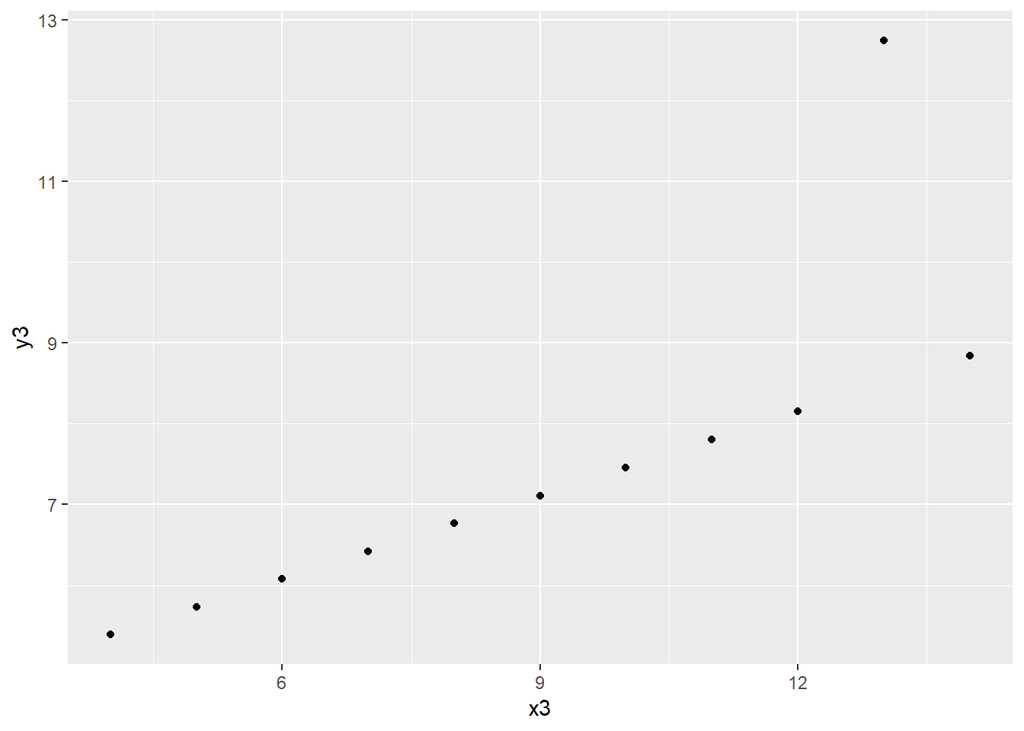

```r
ggplot(data = anscombe, aes(x = x3, y = y3)) +
  geom_point()
```

In this set we have an outlier

- our eyes tell us that with the exception of the outlier the relationship between x and y is perfect
- and in this case it is linear
- however with the presence of the outlier the value of corr coeff is lowered and also the slope of the regression line

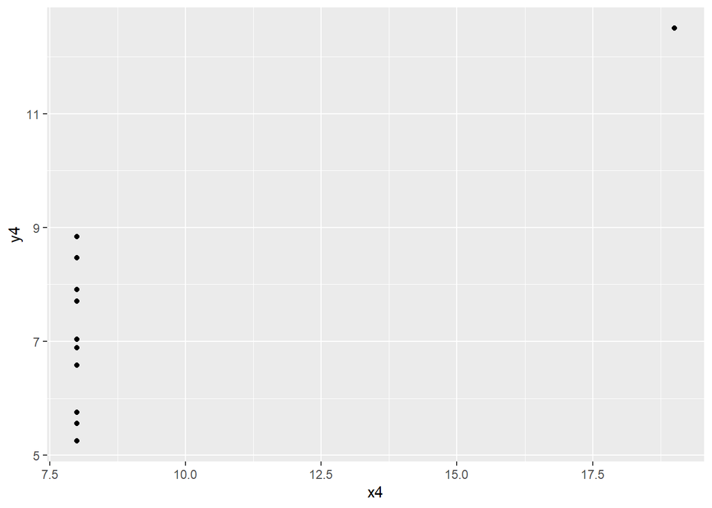

```r
ggplot(data = anscombe, aes(x = x4, y = y4)) +   geom_point()
```

Here we see a pathalogical example with almost the opposite problem

- in the previous example we saw that the presence of single outlier had lowered the corr coeff from 1 to 0.82
- here it raises the corr coeff from undefined to 0.82 * note that here with the exception of the outlier knowing x doesn’t tell us anything about y
- it is only the outlier that gives you the appearance of the correlation but that correlation is suspicious
- the Anscombe datasets are fabricated but they help to illustrate some properties of correlation and thus unscore the importance of visually inspecting a data, a high/low correlation may be due to outlier

## 17.1 Exploring Anscombe

In 1973, Francis Anscombe famously created four datasets with remarkably similar numerical properties, but obviously different graphic relationships. The Anscombe dataset contains the x and y coordinates for these four datasets, along with a grouping variable, set, that distinguishes the quartet.

```r
#names(Anscombe)

#head(Anscombe)

#tail(Anscombe)

names(anscombe)
```

```
## [1] "x1" "x2" "x3" "x4" "y1" "y2" "y3" "y4"
```

```r
head(anscombe)
```

```
##   x1 x2 x3 x4   y1   y2    y3   y4
## 1 10 10 10  8 8.04 9.14  7.46 6.58
## 2  8  8  8  8 6.95 8.14  6.77 5.76
## 3 13 13 13  8 7.58 8.74 12.74 7.71
## 4  9  9  9  8 8.81 8.77  7.11 8.84
## 5 11 11 11  8 8.33 9.26  7.81 8.47
## 6 14 14 14  8 9.96 8.10  8.84 7.04
```

```r
#Transform anscombe to Anscombe format
tmpx = anscombe %>%
  gather(group, x, x1:x4) %>%
  mutate(set = rep(1:4,each=11), id = rep(1:11,4)) %>%
  select(id,set,group,x) %>%
  arrange(id)

tmpx
```

```
##    id set group  x
## 1   1   1    x1 10
## 2   1   2    x2 10
## 3   1   3    x3 10
## 4   1   4    x4  8
## 5   2   1    x1  8
## 6   2   2    x2  8
## 7   2   3    x3  8
## 8   2   4    x4  8
## 9   3   1    x1 13
## 10  3   2    x2 13
## 11  3   3    x3 13
## 12  3   4    x4  8
## 13  4   1    x1  9
## 14  4   2    x2  9
```

[output cut: 30 more lines]

```r
tmpy = anscombe %>%
  gather(group, y, y1:y4) %>%
  mutate(set = rep(1:4,each=11), id = rep(1:11,4)) %>%
  select(id,set,group,y) %>%
  arrange(id)

tmpy
```

```
##    id set group     y
## 1   1   1    y1  8.04
## 2   1   2    y2  9.14
## 3   1   3    y3  7.46
## 4   1   4    y4  6.58
## 5   2   1    y1  6.95
## 6   2   2    y2  8.14
## 7   2   3    y3  6.77
## 8   2   4    y4  5.76
## 9   3   1    y1  7.58
## 10  3   2    y2  8.74
## 11  3   3    y3 12.74
## 12  3   4    y4  7.71
## 13  4   1    y1  8.81
## 14  4   2    y2  8.77
```

[output cut: 30 more lines]

```r
anscombeT = tmpx %>%
  left_join(tmpy, by = c("id","set"))

anscombeT
```

```
##    id set group.x  x group.y     y
## 1   1   1      x1 10      y1  8.04
## 2   1   2      x2 10      y2  9.14
## 3   1   3      x3 10      y3  7.46
## 4   1   4      x4  8      y4  6.58
## 5   2   1      x1  8      y1  6.95
## 6   2   2      x2  8      y2  8.14
## 7   2   3      x3  8      y3  6.77
## 8   2   4      x4  8      y4  5.76
## 9   3   1      x1 13      y1  7.58
## 10  3   2      x2 13      y2  8.74
## 11  3   3      x3 13      y3 12.74
## 12  3   4      x4  8      y4  7.71
## 13  4   1      x1  9      y1  8.81
## 14  4   2      x2  9      y2  8.77
```

[output cut: 30 more lines]

```r
anscombeT = anscombeT %>%
  select(-c(group.x,group.y))

Anscombe = anscombeT

Anscombe
```

```
##    id set  x     y
## 1   1   1 10  8.04
## 2   1   2 10  9.14
## 3   1   3 10  7.46
## 4   1   4  8  6.58
## 5   2   1  8  6.95
## 6   2   2  8  8.14
## 7   2   3  8  6.77
## 8   2   4  8  5.76
## 9   3   1 13  7.58
## 10  3   2 13  8.74
## 11  3   3 13 12.74
## 12  3   4  8  7.71
## 13  4   1  9  8.81
## 14  4   2  9  8.77
```

[output cut: 30 more lines]

It may be helpful to remind yourself of the graphic relationship by viewing the four scatterplots:

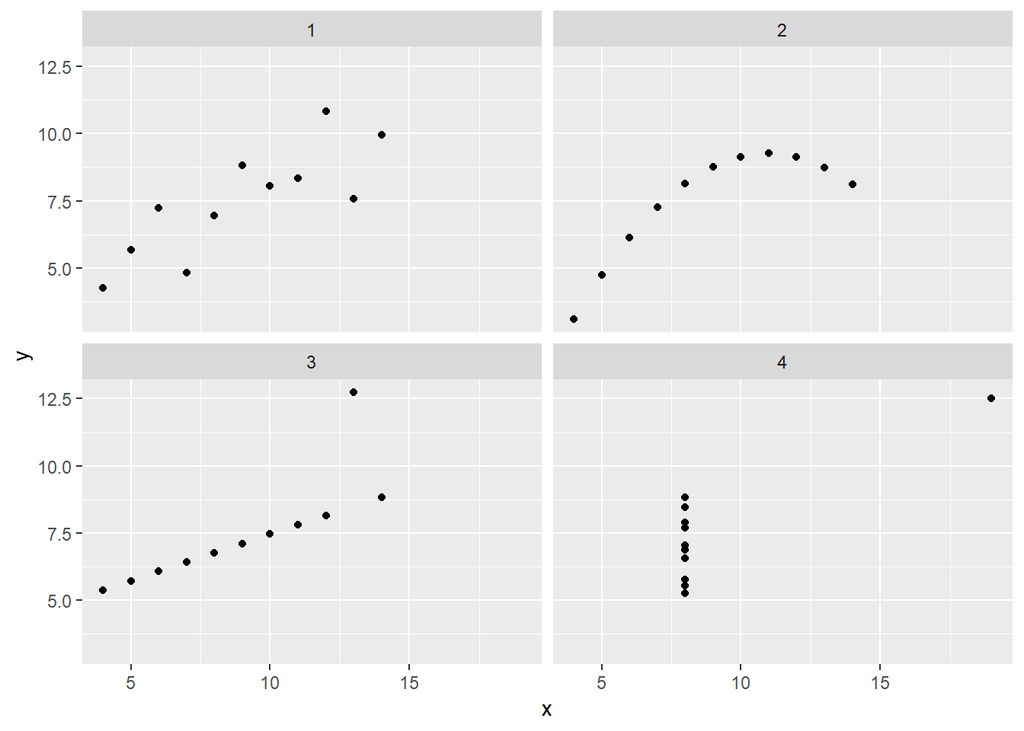

```r
ggplot(data = Anscombe, aes(x = x, y = y)) +
  geom_point() +
  facet_wrap(~set)
```

For each of the four sets of data points in the Anscombe dataset, compute the following in the order specified. Don’t worry about naming any of the variables other than the first in your call to summarize().

Number of observations, N Mean of x Standard deviation of x Mean of y Standard deviation of y Correlation coefficient between x and y

```r
Anscombe %>%
  group_by(set) %>%
   summarise(total = n(), mean(x), sd(x), mean(y), sd(y), cor(x,y))
```

```
## # A tibble: 4 x 7
##     set total `mean(x)` `sd(x)` `mean(y)` `sd(y)` `cor(x, y)`
##   <int> <int>     <dbl>   <dbl>     <dbl>   <dbl>       <dbl>
## 1     1    11         9    3.32      7.50    2.03       0.816
## 2     2    11         9    3.32      7.50    2.03       0.816
## 3     3    11         9    3.32      7.5     2.03       0.816
## 4     4    11         9    3.32      7.50    2.03       0.817
```

```r
 # Compute properties of Anscombe
 Anscombe %>%
   group_by(set) %>%
   summarize(N = n(), mean(x), sd(x), mean(y), sd(y), cor(x, y))
```

```
## # A tibble: 4 x 7
##     set     N `mean(x)` `sd(x)` `mean(y)` `sd(y)` `cor(x, y)`
##   <int> <int>     <dbl>   <dbl>     <dbl>   <dbl>       <dbl>
## 1     1    11         9    3.32      7.50    2.03       0.816
## 2     2    11         9    3.32      7.50    2.03       0.816
## 3     3    11         9    3.32      7.5     2.03       0.816
## 4     4    11         9    3.32      7.50    2.03       0.817
```

Great work! Note that all of the measures are identical (ignoring rounding error) across the four different sets.

## 17.2 Perception of correlation

Estimating the value of the correlation coefficient between two quantities from their scatterplot can be tricky. Statisticians have shown that people’s perception of the strength of these relationships can be influenced by design choices like the x and y scales.

Nevertheless, with some practice your perception of correlation will improve. Toggle through the four scatterplots in the plotting window, each of which you’ve seen in a previous exercise.

Jot down your best estimate of the value of the correlation coefficient between each pair of variables. Then, compare these values to the actual values you compute in this exercise.

Each graph in the plotting window corresponds to an instruction below: Compute the correlation between

```r
glimpse(mlbBat10)
```

```
## Observations: 1,199
## Variables: 19
## $ name     <fct> I Suzuki, D Jeter, M Young, J Pierre, R Weeks, M Scut...
## $ team     <fct> SEA, NYY, TEX, CWS, MIL, BOS, BAL, MIN, NYY, CIN, MIL...
## $ position <fct> OF, SS, 3B, OF, 2B, SS, OF, OF, 2B, 2B, OF, OF, 2B, O...
## $ G        <dbl> 162, 157, 157, 160, 160, 150, 160, 153, 160, 155, 157...
## $ AB       <dbl> 680, 663, 656, 651, 651, 632, 629, 629, 626, 626, 619...
## $ R        <dbl> 74, 111, 99, 96, 112, 92, 79, 85, 103, 100, 101, 103,...
## $ H        <dbl> 214, 179, 186, 179, 175, 174, 187, 166, 200, 172, 188...
## $ `2B`     <dbl> 30, 30, 36, 18, 32, 38, 45, 24, 41, 33, 45, 34, 41, 2...
## $ `3B`     <dbl> 3, 3, 3, 3, 4, 0, 3, 10, 3, 5, 1, 10, 4, 3, 3, 1, 5, ...
## $ HR       <dbl> 6, 10, 21, 1, 29, 11, 12, 3, 29, 18, 25, 4, 10, 25, 1...
## $ RBI      <dbl> 43, 67, 91, 47, 83, 56, 60, 58, 109, 59, 103, 41, 75,...
## $ TB       <dbl> 268, 245, 291, 206, 302, 245, 274, 219, 334, 269, 310...
## $ BB       <dbl> 45, 63, 50, 45, 76, 53, 73, 60, 57, 46, 56, 47, 28, 4...
## $ SO       <dbl> 86, 106, 115, 47, 184, 71, 93, 74, 77, 83, 105, 170, ...
## $ SB       <dbl> 42, 18, 4, 68, 11, 5, 7, 26, 3, 16, 14, 27, 14, 18, 1...
## $ CS       <dbl> 9, 5, 2, 18, 4, 4, 2, 4, 2, 12, 3, 6, 4, 9, 5, 1, 3, ...
## $ OBP      <dbl> 0.359, 0.340, 0.330, 0.341, 0.366, 0.333, 0.370, 0.33...
## $ SLG      <dbl> 0.394, 0.370, 0.444, 0.316, 0.464, 0.388, 0.436, 0.34...
## $ AVG      <dbl> 0.315, 0.270, 0.284, 0.275, 0.269, 0.275, 0.297, 0.26...
```

```r
names(mlbBat10)
```

```
##  [1] "name"     "team"     "position" "G"        "AB"       "R"
##  [7] "H"        "2B"       "3B"       "HR"       "RBI"      "TB"
## [13] "BB"       "SO"       "SB"       "CS"       "OBP"      "SLG"
## [19] "AVG"
```

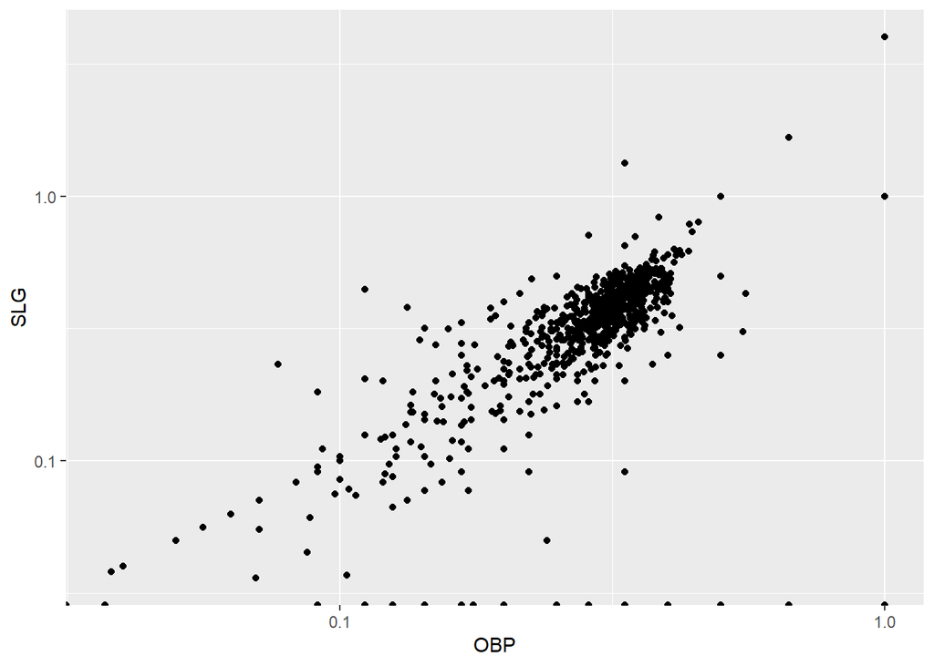

```r
# 1. OBP and SLG for all players in the mlbBat10 dataset

ggplot(mlbBat10, aes(x = OBP, y = SLG)) +
  geom_point() +
  scale_x_log10() +
  scale_y_log10()
```

It’s a fan scatter plot - showing strong positive correlation - 0.82

```r
# Now calculate the actual corr and compare with graphical interpretation

mlbBat10 %>%
  summarise(N = n(), r = cor(OBP, SLG))
```

```
##      N         r
## 1 1199 0.8145628
```

```
 N         r
```

1 1199 0.8145628

2. OBP and SLG for all players in the mlbBat10 dataset with at least 200 at-bats

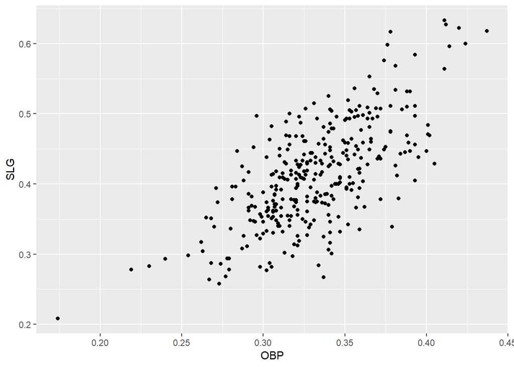

```r
mlbBat10 %>%
  filter(AB >=200) %>%
  ggplot(aes(x = OBP, y = SLG)) +
  geom_point()
```

- the points are spread out so strength is moderate
- direction is positive
- so it is 0.7 correlation

```r
mlbBat10 %>%
  filter(AB >=200) %>%
  summarise(N = n(), r = cor(OBP, SLG))
```

```
##     N         r
## 1 329 0.6855364
```

```
N         r
```

1 329 0.6855364

3. Height and weight for each sex in the bdims dataset # bdims is for body dimensions

```r
names(bdims)
```

```
##  [1] "bia.di" "bii.di" "bit.di" "che.de" "che.di" "elb.di" "wri.di"
##  [8] "kne.di" "ank.di" "sho.gi" "che.gi" "wai.gi" "nav.gi" "hip.gi"
## [15] "thi.gi" "bic.gi" "for.gi" "kne.gi" "cal.gi" "ank.gi" "wri.gi"
## [22] "age"    "wgt"    "hgt"    "sex"
```

```r
str(bdims$sex)
```

```
##  int [1:507] 1 1 1 1 1 1 1 1 1 1 ...
```

```r
unique(bdims$sex)
```

```
## [1] 1 0
```

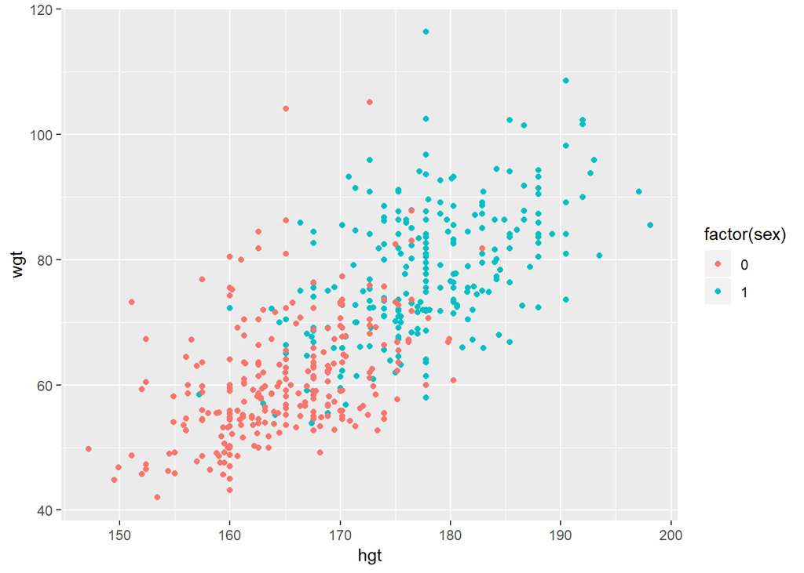

```r
bdims %>%
  group_by(sex) %>%
  ggplot(aes(x = hgt, y = wgt, col = factor(sex))) +
  geom_point()
```

- spread out with few outliers
- direction positive
- sex 1, males have higher - weight
- 0.65 for 0 and 0.7 for 1

```r
bdims %>%
  group_by(sex) %>%
  summarise(N = n(), r = cor(hgt,wgt))
```

```
## # A tibble: 2 x 3
##     sex     N     r
##   <int> <int> <dbl>
## 1     0   260 0.431
## 2     1   247 0.535
```

4. Body weight and brain weight for all species of mammals. Alongside this computation, compute the correlation between the same two quantities after taking their natural logarithms

```r
names(mammals)
```

```
##  [1] "Species"     "BodyWt"      "BrainWt"     "NonDreaming" "Dreaming"
##  [6] "TotalSleep"  "LifeSpan"    "Gestation"   "Predation"   "Exposure"
## [11] "Danger"
```

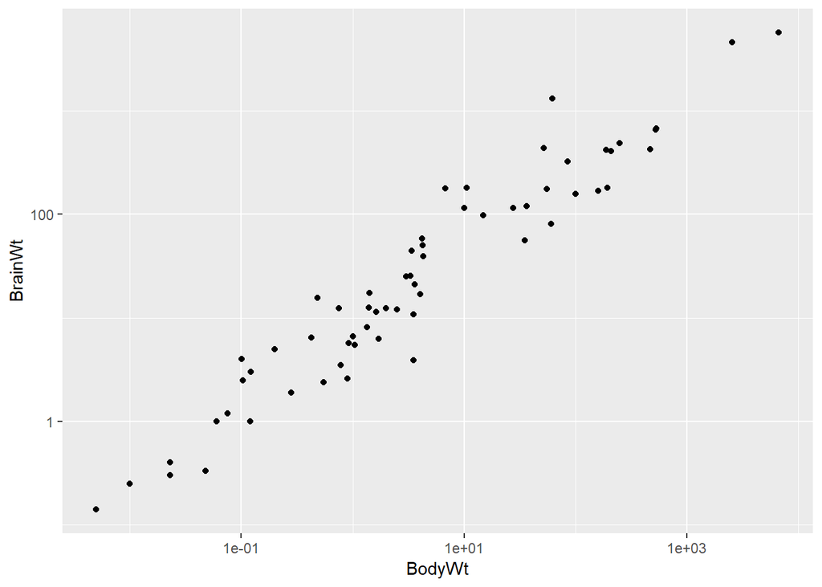

```r
mammals %>%
  ggplot(aes(x=BodyWt, y = BrainWt)) +
  geom_point() +
  scale_x_log10() +
  scale_y_log10()
```

- without log10, shows concetration near origin with two outliers on top, one center top and other right top
- 0.7
- with log10 show strong positive correlation
- almost a straight line, thus showing how accurate value of BrainWt can be predicted give the Body weight or vice-versa
- 0.9

```r
mammals %>%
  summarise(N = n(), r = cor(BodyWt, BrainWt),
            r_log = cor(log(BodyWt), log(BrainWt)))
```

```
##    N         r     r_log
## 1 62 0.9341638 0.9595748
```

Interpretation of correlation

## 17.3 causation

- New york times article about Exercise and beer
- doesn’t demonstrate whether drinking causes exercising or vice-versa
- the best interpretation is quoted from the actual study

‘people drank more than usual on the same days that they engaged in more physical activity than usual.’

- this statement makes clear that an association was observed but does not try to imply causality
- in observational studies which are especially common in nutritional science health and epidemiology
- one must be careful to not erroroneously suggest that correlation implies caussation
- let’s look at the study of NFL (National Football League) players
- and whether few franchises tend to have more palyers arrested over time
- this use of correlation often called serial correlation or auto-correlation checks to see whether its single numeric variable is highly correlated with past measurements of itself
- from the plot and reported 0.53 correlation we see some relation with the number of players arrested from each team during the revenue periof of 2000 to 2006 was positively associated with the number of players arrested by the same team during the subsequent seven year period from 2007 to 2013
- the author interprets both the plot and reported pretty solid correlation as the evidence of a team specific effect without offering explanations or implying cause and effect
- the author effectively communicates the player arrests in NFL do not appear to be randomly distributed across team but rather that the certain teams may have player acquisition philosophies that result in them having higher number of players arrested
- sometimes journalists can leave statistics concepts lost in translation
- for example below sentence in an article reports ‘no correlation was found between economic growth and lower tax rates at the top of the income bracket’
- this is a politically sensitive finding but we’re interested in the word correlation here
- it is not being used in its precise political sense
- the link to the actual report reveals that the findings are based on a multiple regression model not a simple correlation
- where more that one explanatory variables are taken into account which is impossible to do with correlation which is a simple bivariate statistic
- finally it is not uncommon to encounter references to a plot of correlation
- this doesn’t quite make sense
- of course a scatter plot may be a graphical presentation of two variables and the strength of the linear relationship shown can be neatly summarized by a correlation
- in this case the article refers to a table of correlation between several variables often called the correlation matrix as a plot of correlation
- let’s interprete correlation like a pro

## 17.4 Interpreting correlation in context

Recall that you previously determined the value of the correlation coefficient between the poverty rate of counties in the United States and the high school graduation rate in those counties was -0.681. Choose the correct interpretation of this value.

Possible Answers People who graduate from high school are less likely to be poor. { not correct - Beware the ecological fallacy!}

Counties with lower high school graduation rates are likely to have lower poverty rates.

Counties with lower high school graduation rates are likely to have higher poverty rates. (correct answer)

Because the correlation is negative, there is no relationship between poverty rates and high school graduate rates.

Having a higher percentage of high school graduates in a county results in that county having lower poverty rates. (Answer) - Wrong Correlation does not imply causation! {the word results}

## 17.5 Correlation and Causation

In the San Francisco Bay Area from 1960-1967, the correlation between the birthweight of 1,236 babies and the length of their gestational period was 0.408. Which of the following conclusions is not a valid statistical interpretation of these results.

Possible Answers We observed that babies with longer gestational periods tended to be heavier at birth.

It may be that a longer gestational period contributes to a heavier birthweight among babies, but a randomized, controlled experiment is needed to confirm this observation.

Staying in the womb longer causes babies to be heavier when they are born. { the word causes cannot be used for a study on observation } (answer - Right! Correlation does not imply causation!Hence this statement is not valid statistical interpretation)

These data suggest that babies with longer gestational periods tend to be heavier at birth, but there are many potential confounding factors that were not taken into account.

## 17.6 Spruious correlation

- correlation does not imply causation, that is it does not mean that changes in one are causing changes in the other
- there are many potential confounders that coud cloud our ability to determine cause and effect
- remarkable but non-sensical correlations are called spurious {spurious - not being what it purports to be; false or fake }
- for example number of films Nocholas Cage appeared in correlates with the number of people drawn by falling in a pool
- are these variables related by any substantive means, of course not
- here’s another example that traces US oil production to the quality of rock music
- I suppose one may need to burn the midnight oil to make a truly enduring rock classic
- in each of these cases the correlation was illustrated as two variables that seem to move together over time
- in fact time is an obvious confounder for many of these spurious correlations
- anytime you see two variables linked over time, you should be skeptical about the role time can play as a confounder
- this web comic from xkcd illustrates how space can also be present in spurious correlations
- coloured map called coral-plates ??? can be visually arresting way to convey information
- but they can also reveal spurious correlations
- many things occur more often in places where there are more people
- so the failure to control for the confounding – population can lead to spurious information
- in other cases it may not be easy to determine what confounding varaibles are driving the spurious correaltion

Spurious for whatever reason (neither time nor space …) * scatter plot shows for the number of lemons imported into the US from Mexico has increase the the total fatality rate in US has decreased * the relationship appears to be strong but of course there is no plausible causative mechanism that could explain the relationship * this is mostly likely due to chance * the scrupulous statistician must always be on the look out for such spurious correlations {scrupulous - careful, thorough and extremely attentive to details}

## 17.7 Spurious correlation in random data

Statisticians must always be skeptical of potentially spurious correlations. Human beings are very good at seeing patterns in data, sometimes when the patterns themselves are actually just random noise. To illustrate how easy it can be to fall into this trap, we will look for patterns in truly random data.

The noise dataset contains 20 sets of x and y variables drawn at random from a standard normal distribution. Each set, denoted as z, has 50 observations of x, y pairs. Do you see any pairs of variables that might be meaningfully correlated? Are all of the correlation coefficients close to zero?

## 17.8 Random numbers: runif() rnorm()

R has functions to generate a random number from many standard distribution like uniform distribution, binomial distribution, normal distribution etc. …

For example, runif() generates random numbers from a uniform distribution and { vertiicle or horizonal ?? }

rnorm() generates from a normal distribution {bell shaped}

```r
#create the noise data frame
rm(noise)
set.seed(123)
x = rep(rnorm(50), 20)
y = rep(rnorm(50), 20)

noise = data.frame(x = x, y = y, z = rep(1:20,50))

names(noise)
```

```
## [1] "x" "y" "z"
```

```r
head(noise)
```

```
##             x           y z
## 1 -0.56047565  0.25331851 1
## 2 -0.23017749 -0.02854676 2
## 3  1.55870831 -0.04287046 3
## 4  0.07050839  1.36860228 4
## 5  0.12928774 -0.22577099 5
## 6  1.71506499  1.51647060 6
```

Create a faceted scatterplot that shows the relationship between each of the 20 sets of pairs of random variables x and y. You will need the facet_wrap() function for this.

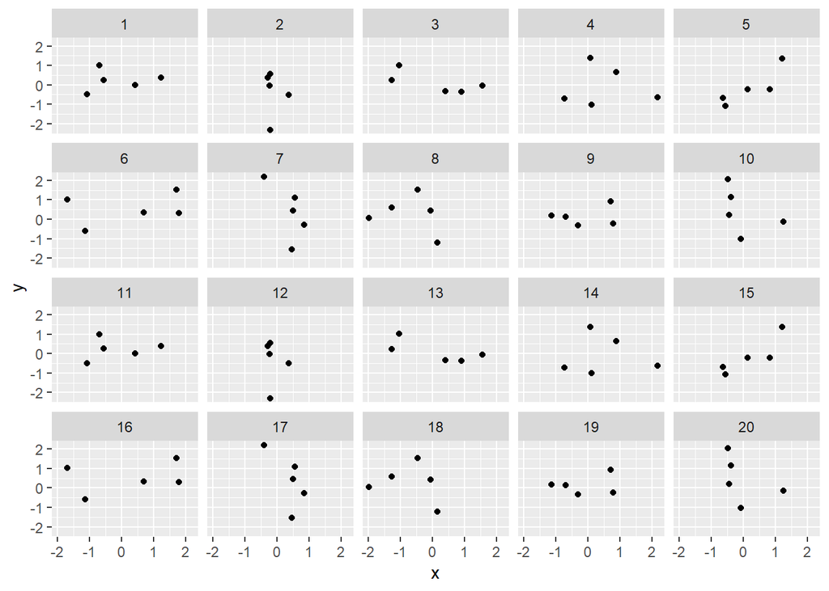

```r
noise %>%
  ggplot(aes(x = x, y = y)) +
  geom_point() +
  facet_wrap(~ z)
```

Correlation interpretaion based on graph for eachh of 20 sets { ability to predict y for given x or vice-versa }

1 - weak corr - .3 (0.154) 2 - weak corr - .1 (-0.0999) 3 - non-linear - 0.4 (-0.698 )

4 - weak - negative - dispersed points - (-0.0277) 5 - moderte positive - 0.5 (0.869 ) 6 - no corr - (0.310 ) 7 - weak - (-0.662 ) - straing line with slight backward slope so it is easy to predict value of y for given x

8 - weak neg ( -0.220 )

9 - dispersed curve - weak pos - 0.3 (0.214 )

11 - moderate pos - 0.4 ( 0.154 )

12 - weak neg - -0.0999

13 - moderate neg - -0.698

14 - dispersed points - weak neg - -0.0277

15 - strong pos - 0.869

16 - dispersed - weak pos - 0.310

17 - dense straight - moderate neg - -0.662

18 - dispersed neg - -0.220

19 - curve pos - 0.214

```r
noise_summary = noise %>%
  group_by(z) %>%
  summarise(N = n(), spurious_cor = cor(x,y))

noise_summary
```

```
## # A tibble: 20 x 3
##        z     N spurious_cor
##    <int> <int>        <dbl>
##  1     1    50       0.154
##  2     2    50      -0.0999
##  3     3    50      -0.698
##  4     4    50      -0.0277
##  5     5    50       0.869
##  6     6    50       0.310
##  7     7    50      -0.662
##  8     8    50      -0.220
##  9     9    50       0.214
## 10    10    50      -0.441
## 11    11    50       0.154
## 12    12    50      -0.0999
## 13    13    50      -0.698
## 14    14    50      -0.0277
## 15    15    50       0.869
## 16    16    50       0.310
## 17    17    50      -0.662
## 18    18    50      -0.220
## 19    19    50       0.214
## 20    20    50      -0.441
```

Identify the datasets that show non-trivial correlation ofgreater than 0.2 in absolute value.

```r
noise_summary %>%
  filter( abs(spurious_cor) > 0.2)
```

```
## # A tibble: 14 x 3
##        z     N spurious_cor
##    <int> <int>        <dbl>
##  1     3    50       -0.698
##  2     5    50        0.869
##  3     6    50        0.310
##  4     7    50       -0.662
##  5     8    50       -0.220
##  6     9    50        0.214
##  7    10    50       -0.441
##  8    13    50       -0.698
##  9    15    50        0.869
## 10    16    50        0.310
## 11    17    50       -0.662
## 12    18    50       -0.220
## 13    19    50        0.214
## 14    20    50       -0.441
```

# 18 Visualization of linear models

Before we get into the mathematical specification for a regression model, let’s build an intuition of what a regression line is.

```r
names(possum)
```

```
## [1] "site"   "pop"    "sex"    "age"    "headL"  "skullW" "totalL" "tailL"
```

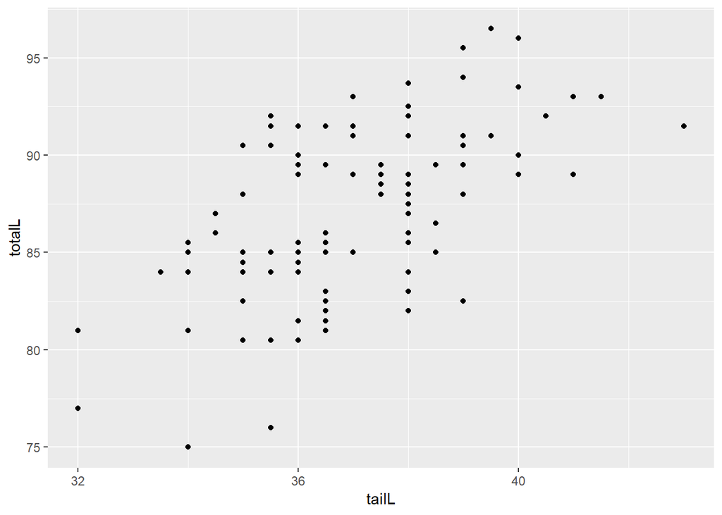

```r
ggplot(data = possum, aes(y = totalL, x = tailL)) +
  geom_point()
```

scatter plot is dispersed implying it is not a perfect relationship

- for the same tailL the totalL varies
- but we still have a intuitive desire to describe the relatioship with a line
- this line goes through the origin, where both x and y are equal to zero
- and a slope of 2.5 cm per cm

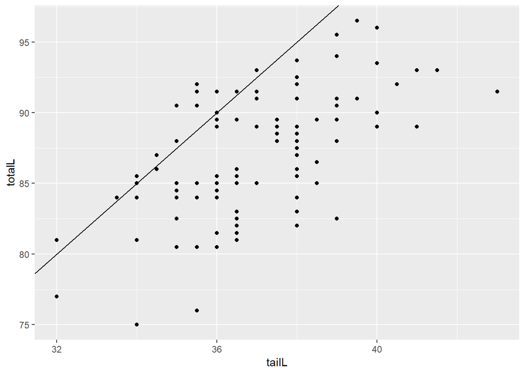

```r
ggplot(data = possum, aes(y = totalL, x = tailL)) +
  geom_point() +
  geom_abline(intercept = 0, slope = 2.5)
```

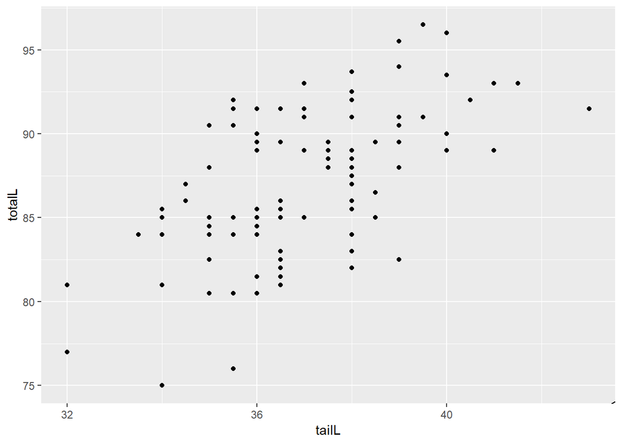

```r
ggplot(data = possum, aes(y = totalL, x = tailL)) +
  geom_point() +
  geom_abline(intercept = 0, slope = 1.7)
```

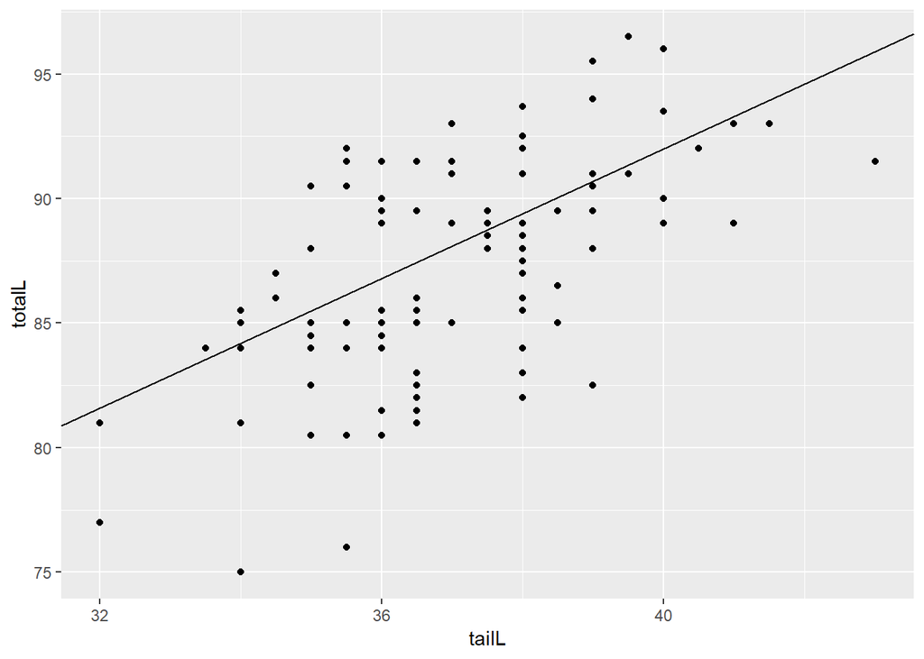

```r
ggplot(data = possum, aes(y = totalL, x = tailL)) +
  geom_point() +
  geom_abline(intercept = 40, slope = 1.3)
```

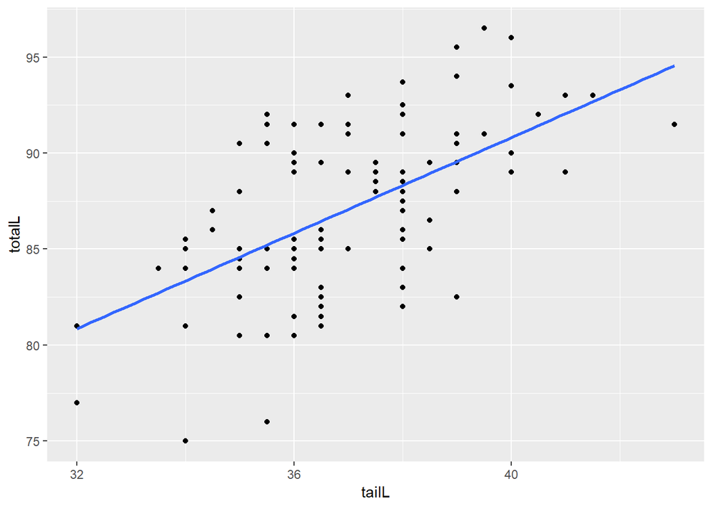

```r
# Ignore the standard errors
ggplot(data = possum, aes(y = totalL, x = tailL)) +
  geom_point() + geom_smooth(method = "lm", se = FALSE)
```

# 19 The ‘best fit’ line

The simple linear regression model for a numeric response as a function of a numeric explanatory variable can be visualized on the corresponding scatterplot by a straight line. This is a ‘best fit’ line that cuts through the data in a way that minimizes the distance between the line and the data points.

We might consider linear regression to be a specific example of a larger class of smooth models. The geom_smooth() function allows you to draw such models over a scatterplot of the data itself. This technique is known as visualizing the model in the data space.

The method argument to geom_smooth() allows you to specify what class of smooth model you want to see. Since we are exploring linear models, we’ll set this argument to the value ‘lm’.

Note that geom_smooth() also takes an se argument that controls the standard error, which we will ignore for now.

Create a scatterplot of body weight as a function of height for all individuals in the bdims dataset with a simple linear model plotted over the data.

```r
names(bdims)
```

```
##  [1] "bia.di" "bii.di" "bit.di" "che.de" "che.di" "elb.di" "wri.di"
##  [8] "kne.di" "ank.di" "sho.gi" "che.gi" "wai.gi" "nav.gi" "hip.gi"
## [15] "thi.gi" "bic.gi" "for.gi" "kne.gi" "cal.gi" "ank.gi" "wri.gi"
## [22] "age"    "wgt"    "hgt"    "sex"
```

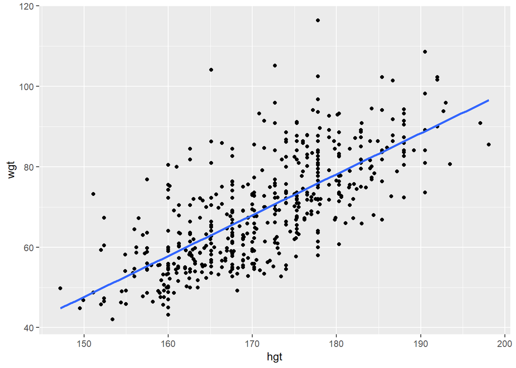

```r
ggplot(bdims, aes(x = hgt, y = wgt)) +
  geom_point() +
  geom_smooth(method = "lm", se = FALSE)
```

## 19.1 Uniqueness of least squares regression line

The least squares criterion implies that the slope of the regression line is unique. In practice, the slope is computed by R. In this exercise, you will experiment with trying to find the optimal value for the regression slope for weight as a function of height in the bdims dataset via trial-and-error.

To help, we’ve built a custom function for you called add_line(), which takes a single argument: the proposed slope coefficient.

The bdims dataset is available in your workspace. Experiment with different values (to the nearest integer) of the my_slope parameter until you find one that you think fits best.

slope of 1 was best fit

# 20 Understanding the linear model

- models are ubiquitous in statistics
- in many cases we assume that the value of our response variable is some function of our explanatory variable plus some random noise

*General statistical model*

$$response = f(explanatory) + noise$$

- the later term is important in a philosophical sense it is a signal of statistical thinking
- what we are saying is that there is some mathematical function f which can translate the values of one variable into values of another
- except that there is some randomness in the process
- what distinquishes statisticians from other quantitative researchers is the way we try to model that random noise
- for a linear regression model we simply assume that f takes the form of a linear function
- thus our model describes the value of the response variable in terms of an intercept and a slope

$$response = intercept + (slope*explanatory) + noise$$

# 21 Regression model

- mathematically intercept is beta0, slope as beta1 and noise as epsilon having a normal distribuiton with mean zero and a fixed sd
- understanding the specification of this noise term is crucial to thinking like a statistician

## 21.1 Fitted values

- y is actual observed value of response
- y hat is expected value of response based on the model
- difference between these two quantities is called residuals e = y - y’
- residuals are the realisations of the noise term
- e is a known estimate of the unknow epsilon

## 21.2 Fitting procedure

- given n observations of x,y pairs the procedure finds its estimates of intercept and slope that minimize the sum of squared residuals

## 21.3 Least squares procedure

- is easy, deterministic and returns a unique solution
- residuals are guaranteed to sum to zero
- and a poitn x’,y’ is guaranteed to lie on the regression line
- regression slope and correlation coeff are closely related
- infact they’re proportional to one another
- you should also be aware that other criteria, apart from these squares exist
- just not in this course

## 21.4 Key concepts about regression lines

- the fiited values y-hat are the expected values given the corresponding value x
- it is not always the case thet x will translate to y-hat it is just that y-hat is our best guess for the true value of y given what we know about x
- in the same way that the fitted intercept and slope are the estimates of the true unknown intercept and slope
- residuals e’s are the estimates of the true unknown epsilons
- these noise terms may be referred to as errors, but it suggests something is wrong, whereas it is only the random variation inherent in physical processes
- and we’re hoping to capture that random noise, so better term is noise

In Hampshire County in western Massachusetts, the high school graduation rate is 92.4%. These two facts imply that the poverty rate in Hampshire County is ___.

Possible Answers

exactly 11.7%

exactly 10.0%

expected to be about 10.0% (answer)

expected to be about 11.7%

64.594 - 0.591*92.4 9.9856

Two facts enable you to compute the slope b1 and intercept b0 of a simple linear regression model from some basic summary statistics.

The bdims_summary data frame contains all of the information you need to compute the slope and intercept of the least squares regression line for body weight (Y) as a function of height (X). You might need to do some algebra to solve for b0!

```r
bdims_summary = bdims %>%
  summarize(N = n(), r = cor(hgt,wgt),
            mean_hgt = mean(hgt), sd_hgt = sd(hgt),
            mean_wgt = mean(wgt), sd_wgt = sd(wgt))

bdims_summary
```

```
##     N         r mean_hgt   sd_hgt mean_wgt   sd_wgt
## 1 507 0.7173011 171.1438 9.407205 69.14753 13.34576
```

Use mutate() to add the slope and intercept to the bdims_summary data frame.

$$slope = r(x,y).sd(y)/sd(x)$$

$$intercept = mean(y) - slope.mean(x)$$

linear model calculates weight as a function of height.

$$y - wgt x - hgt$$

Add slope and intercept

```r
bdims_summary %>%
  mutate(slope = r*sd_wgt/sd_hgt,
         intercept = mean_wgt - slope*mean_hgt)
```

```
##     N         r mean_hgt   sd_hgt mean_wgt   sd_wgt    slope intercept
## 1 507 0.7173011 171.1438 9.407205 69.14753 13.34576 1.017617 -105.0113
```

# 22 Regression vs. regression to the mean

Galton’s ‘regression to the mean’

- it is a distinct concept than linear regression
- let’s start with a question
- do tall men tend to beget tall sons?
- do tall women tend to beget tall daughters?
- consider these question in terms of professional basket ball players
- do you expect children of 7 foot tall men to be exceptionally tall
- the answer turns out be yes, but not as tall as their fathers
- this is infact what Galton deemed as regression to the mean

Regression to the mean is a concept attributed to Sir Francis Galton. The basic idea is that extreme random observations will tend to be less extreme upon a second trial. This is simply due to chance alone. While ‘regression to the mean’ and ‘linear regression’ are not the same thing, we will examine them together in this exercise.

One way to see the effects of regression to the mean is to compare the heights of parents to their children’s heights. While it is true that tall mothers and fathers tend to have tall children, those children tend to be less tall than their parents, relative to average. That is, fathers who are 3 inches taller than the average father tend to have children who may be taller than average, but by less than 3 inches.

## 22.1 Regression modeling

- ‘Regression’: techniques for modeling a quantitative response
- we’re persuing least squares regression models but there are a number of regression model specifications
- additionally there are models like regression trees that also estimate a single numerical response but do not use a linear framework as we do in this course

Types of regression models :

1. Least squares
2. Weighted
3. Generalized
4. Nonparametric
5. Ridge
6. Baysian …

## 22.2 ?GaltonFamilies

A data frame with 934 observations on the following 8 variables.

family family ID, a factor with levels 001-204

father height of father

mother height of mother

midparentHeight mid-parent height, calculated as (father + 1.08*mother)/2

children number of children in this family

childNum number of this child within family. Children are listed in decreasing order of height for boys followed by girls

gender child gender, a factor with levels female male

childHeight height of child

```r
#install.packages("HistData")
library(HistData)
names(Galton)
```

```
## [1] "parent" "child"
```

```r
nrow(Galton)
```

```
## [1] 928
```

```r
head(Galton)
```

```
##   parent child
## 1   70.5  61.7
## 2   68.5  61.7
## 3   65.5  61.7
## 4   64.5  61.7
## 5   64.0  61.7
## 6   67.5  62.2
```

```r
names(GaltonFamilies)
```

```
## [1] "family"          "father"          "mother"          "midparentHeight"
## [5] "children"        "childNum"        "gender"          "childHeight"
```

```r
nrow(GaltonFamilies)
```

```
## [1] 934
```

```r
glimpse(GaltonFamilies)
```

```
## Observations: 934
## Variables: 8
## $ family          <fct> 001, 001, 001, 001, 002, 002, 002, 002, 003, 0...
## $ father          <dbl> 78.5, 78.5, 78.5, 78.5, 75.5, 75.5, 75.5, 75.5...
## $ mother          <dbl> 67.0, 67.0, 67.0, 67.0, 66.5, 66.5, 66.5, 66.5...
## $ midparentHeight <dbl> 75.43, 75.43, 75.43, 75.43, 73.66, 73.66, 73.6...
## $ children        <int> 4, 4, 4, 4, 4, 4, 4, 4, 2, 2, 5, 5, 5, 5, 5, 6...
## $ childNum        <int> 1, 2, 3, 4, 1, 2, 3, 4, 1, 2, 1, 2, 3, 4, 5, 1...
## $ gender          <fct> male, female, female, female, male, male, fema...
## $ childHeight     <dbl> 73.2, 69.2, 69.0, 69.0, 73.5, 72.5, 65.5, 65.5...
```

```r
str(GaltonFamilies$family)
```

```
##  Factor w/ 205 levels "001","002","003",..: 1 1 1 1 2 2 2 2 3 3 ...
```

Create below subsets

```r
Galton_men = GaltonFamilies %>%
  filter(gender == "male") %>%
  mutate(sex = gender, height = childHeight, nkids = children) %>%
  select(family,father,mother,sex,height,nkids)


glimpse(Galton_men)
```

```
## Observations: 481
## Variables: 6
## $ family <fct> 001, 002, 002, 003, 004, 004, 005, 005, 005, 007, 007, ...
## $ father <dbl> 78.5, 75.5, 75.5, 75.0, 75.0, 75.0, 75.0, 75.0, 75.0, 7...
## $ mother <dbl> 67.0, 66.5, 66.5, 64.0, 64.0, 64.0, 58.5, 58.5, 58.5, 6...
## $ sex    <fct> male, male, male, male, male, male, male, male, male, m...
## $ height <dbl> 73.2, 73.5, 72.5, 71.0, 70.5, 68.5, 72.0, 69.0, 68.0, 7...
## $ nkids  <int> 4, 4, 4, 2, 5, 5, 6, 6, 6, 6, 6, 6, 6, 8, 8, 2, 2, 2, 3...
```

```r
# tranform family from 001,002 to 1,2...
Galton_men$family = as.factor(as.numeric(Galton_men$family))

str(Galton_men$family)
```

```
##  Factor w/ 179 levels "1","2","3","4",..: 1 2 2 3 4 4 5 5 5 6 ...
```

```r
# tranform sex levels from female, male to F,M and drop unused levels
levels(Galton_men$sex)
```

```
## [1] "female" "male"
```

```r
Galton_men$sex = droplevels(Galton_men$sex)

levels(Galton_men$sex)
```

```
## [1] "male"
```

```r
levels(Galton_men$sex) = "M"

levels(Galton_men$sex)
```

```
## [1] "M"
```

```r
glimpse(Galton_men)
```

```
## Observations: 481
## Variables: 6
## $ family <fct> 1, 2, 2, 3, 4, 4, 5, 5, 5, 7, 7, 7, 7, 11, 11, 13, 14, ...
## $ father <dbl> 78.5, 75.5, 75.5, 75.0, 75.0, 75.0, 75.0, 75.0, 75.0, 7...
## $ mother <dbl> 67.0, 66.5, 66.5, 64.0, 64.0, 64.0, 58.5, 58.5, 58.5, 6...
## $ sex    <fct> M, M, M, M, M, M, M, M, M, M, M, M, M, M, M, M, M, M, M...
## $ height <dbl> 73.2, 73.5, 72.5, 71.0, 70.5, 68.5, 72.0, 69.0, 68.0, 7...
## $ nkids  <int> 4, 4, 4, 2, 5, 5, 6, 6, 6, 6, 6, 6, 6, 8, 8, 2, 2, 2, 3...
```

```r
481-465
```

```
## [1] 16
```

Follow similar steps for creating Galton_women

```r
Galton_women = GaltonFamilies %>%
  filter(gender == "female") %>%
  mutate(sex = gender, height = childHeight, nkids = children) %>%
  select(family,father,mother,sex,height,nkids)

glimpse(Galton_women)
```

```
## Observations: 453
## Variables: 6
## $ family <fct> 001, 001, 001, 002, 002, 003, 004, 004, 004, 005, 005, ...
## $ father <dbl> 78.5, 78.5, 78.5, 75.5, 75.5, 75.0, 75.0, 75.0, 75.0, 7...
## $ mother <dbl> 67.0, 67.0, 67.0, 66.5, 66.5, 64.0, 64.0, 64.0, 64.0, 5...
## $ sex    <fct> female, female, female, female, female, female, female,...
## $ height <dbl> 69.2, 69.0, 69.0, 65.5, 65.5, 68.0, 67.0, 64.5, 63.0, 6...
## $ nkids  <int> 4, 4, 4, 4, 4, 2, 5, 5, 5, 6, 6, 6, 1, 6, 6, 3, 3, 3, 1...
```

```r
levels(Galton_women$sex)
```

```
## [1] "female" "male"
```

```r
Galton_women$sex = droplevels(Galton_women$sex)

levels(Galton_women$sex)
```

```
## [1] "female"
```

```r
levels(Galton_women$sex) = "F"

levels(Galton_women$sex)
```

```
## [1] "F"
```

```r
nrow(Galton_women)
```

```
## [1] 453
```

Create a scatterplot of the height of men as a function of their father’s height. Add the simple linear regression line and a diagonal line (with slope equal to 1 and intercept equal to 0) to the plot.

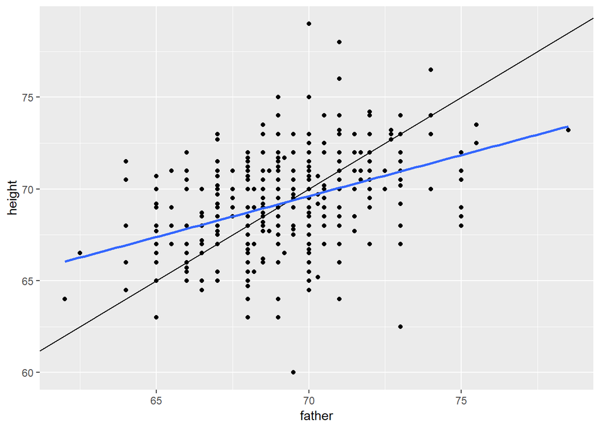

```r
# Height of male children vs. height of father
# y = height, x = father, slope =1, intercept = 0

ggplot(Galton_men, aes(x = father, y = height)) +
  geom_point() +
  geom_abline(slope = 1, intercept = 0) +
  geom_smooth(method = "lm", se = FALSE)
```

Create a scatterplot of the height of women as a function of their mother’s height. Add the simple linear regression line and a diagonal line to the plot.

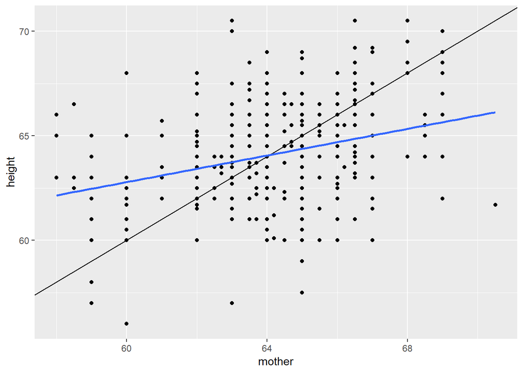

```r
# Height of female children vs. height of mother
# y = height, x = mother

ggplot(Galton_women, aes(x = mother, y = height)) +
  geom_point() +
  geom_abline(slope = 1, intercept = 0) +
  geom_smooth(method = "lm", se = FALSE)
```

Conclusion: Excellent! Because the slope of the regression line is smaller than 1 (the slope of the diagonal line) for both males and females, we can verify Sir Francis Galton’s regression to the mean concept!